# By Sound Alone

Mark Torrey (bysoundalone.net)

(Version-date: February 8, 2024) © 2024 Mark Torrey, CC BY-NC-SA

## Three things to do if you enjoy this book

1. If you only do one thing, pass the book on! Julian Barnes points out that for every book somebody, somewhere, someday will be the last reader of that book. *Please* don’t be my last reader! I don’t need your money, or love, or nomination for a MacArthur grant. All I need is for you to pass on your copy of this book to someone else. Hopefully with at least as much of an endorsement as “Well, you know, it’s worth a read.”
2. I encourage you to sign up for the mailing list. There will be no spam. There will be very little email at all. Mostly it’s a way for me to make sure the people who are most interested in my work will know about new stuff when it becomes available.

   You can request to be added to the mailing list here:  
   https://grannycart.net/contact

   Getting on the email list is one of the most important things you can do to support creative work you admire because it is the only way creators can stay in touch that doesn’t depend on some corporate platform that could be taken over by a megalomaniacal billionaire and driven into the ground at any time. You should sign up for the email list of anyone whose work you value. By doing so you are giving them the gift of empowerment. In many ways it’s more important than money.
3. If you have the means, consider donating something to a worthy cause. May I recommend Los Deliveristas Unidos, a group working toward giving delivery workers who work through apps like GrubHub, DoorDash, and Uber Eats access to basic labor rights. Los Deliveristas Unidos is a project of the [Worker’s Justice Project](http://www.workersjustice.org/workers-justice-project), which organizes to win better living and working conditions for gig workers and migrants in New York City.

   You can donate here:  
   https://secure.actblue.com/donate/workersjustice

## Diagrams

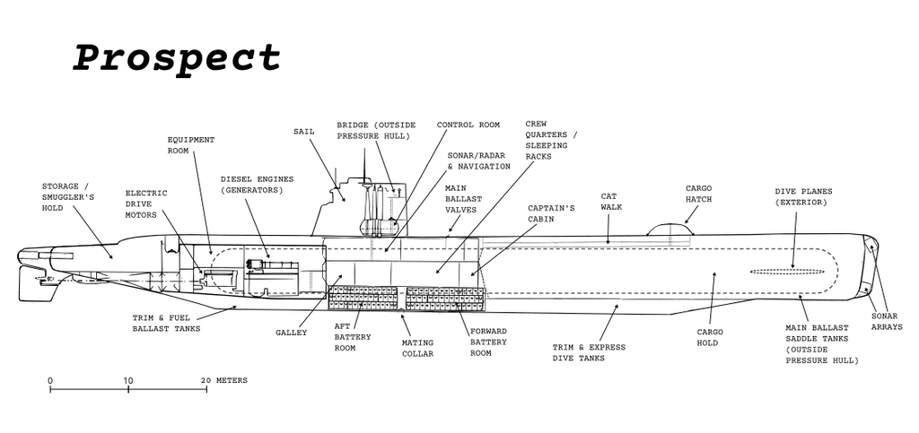

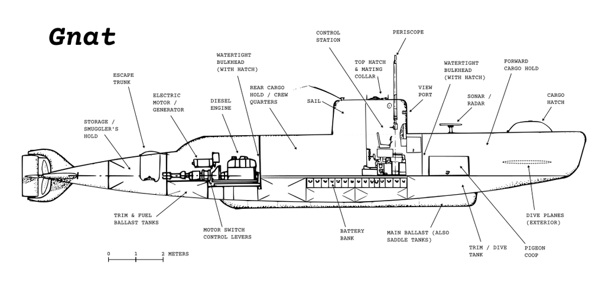

## Preface

You can skip this preface. Go ahead, I don’t mind at all. Actually, I encourage you to. I’d much prefer you dove directly into the story than have you slog through these first thousand words or so for no other reason than a sense of duty or a need to complete things. “Entertainment first” is the rule here!

But if you are among those inclined to wring the most you possibly can from a book — or if you’ve already *read* this book and are back for a second pass to try to wring a bit more out of it — well, then, for you I’ve got this preface to maybe shed some light on a few of the more obscure themes of the book. If you do finish the preface, you may stand to gain an ever-so-slightly fuller experience when you hit the book itself. And hey, that’s a kind of entertainment too.

The core of the book (and, OK, it’s not actually obscure in any way) is an exploration of how humans live with their machines. Today we have more machines doing things for us than ever before, but the premise of this book is that there is something special about the human relationship to *mechanical* machines. This book is about a particular type of human interaction with machines — the type that makes the human a “mechanic.”

In the latter part of the nineteenth century and through most of the twentieth Century, technology changed the world. But the technology of that time was different from ours. It was rooted in mechanical and electrical things. Back then, anyone who wanted to understand how a piece of amazing new technology worked could simply take it apart. Most things had an intuitive structure — mechanical solutions based on logical processes. This is not the same as being *simple*. Many things from that era were in fact far more complex than today’s equivalent devices. But learning how machines worked — and how to repair them — only required a willingness to disassemble (and then, gaining a bunch of experience putting things back together). Most parts also had a macroscopic quality. They worked on a human scale. You could see the parts without magnification, you could place a part where it belonged with your fingers rather than any kind of special tool. Today, technology is changing the world again. But if you take apart a contemporary technical object, all you will find is vanishingly small components that cannot be repaired, only replaced. And sometimes even the creators do not understand how they work.

Because of its mechanical underpinnings, that old technology also just *behaved* more rationally. Even people without the faintest grasp of mechanical fundamentals, could learn how their machine would behave just through using it. A good mechanic could tell by *feel* that something was going wrong and could often guess which specific part was failing, without randomness manifesting itself in the system. People could depend on their technology to behave intuitively when they used it, unlike today, when even experts can be shocked by the behavior of digital-based technology and find themselves at a loss to explain it.

This old technology also came with an aesthetic. Its mechanical nature made it dirty, greasy, and grimy. It was powered by the air-fouling burning of material, kept lubricated by chemical greases, and cleaned with penetrating toxic solvents. This aesthetic permeated our culture. The rich found ways to constantly clean it. The poor and the technology maintainers simply lived in and among the grime.

Stories from that mechanical age are often gripping because they tell of average people achieving amazing things with the exciting new tools available to them. Often those average people made their extraordinary tools and technologies perform far beyond their originally intended use. To this day, people still delight in stories of electro-mechanical machines. Indeed, we may yet still be more engaged with electro-mechanical stories than with stories derived from our modern technology: nearly everyone would rather watch the building of a custom motorcycle than admire the latest achievements from a microchip clean-room. It is even possible that the pleasures offered by mechanical things goes much deeper in the mammalian psyche than just human consciousness: it has been shown that if wild mice in a forest are given a wheel, they will choose to spend their idle time spinning away.

The story told in this book is hung on technologies that anyone could understand with nothing more than a little time pondering in their armchair. The world this story lives in is confined to technology that is *non-magical* and accessible. Mechanics become the medium for the story. More than that, I hope the reader who rides along with those who try to live among those machines can also *feel* how the machines behave, what they can and cannot do. When this works, it becomes possible to leverage the reader’s sense of how machines behave to a point where high drama can be derived from nothing more than the movements of a needle on a dial.

Today’s technology has crossed a line into the magical, and there is no way to put that technology back in the bottle even if we wanted to. But in the context of fiction, we may imagine a world where the electro-mechanical remained the dominant root of our everyday technology for far longer than it did. It is possible to imagine that, had the geopolitical and economic winds blown in a slightly different direction, commerce and industry could still be carried out by independent operators driving grease-coated machines steered by mechanical linkages. Such is the world of this book.

—M. Torrey, July 2023

## 1. Tablemount

The weight of the atmosphere pressed the night down on the ocean. The air above the black water was pinned under a murky dome of heavy cloud, held down like a dying songbird gripped in the claws of some great hunting feline. The weight compressed the air to complete stillness, flattening the water until it was unable to raise more than a barely perceptible heave, forced up from the hidden reserves of power somewhere deep below the glassy surface.

A distant moon — cast out by the atmosphere and not visible — dimly lit the clouds to the color of the charred edges of a coal. The moon reclined, above and beyond, unable to muster enough warmth to intervene with the iron grip of the atmospheric pressure. It merely stood by helplessly, feebly attempting to stir the ocean out from under the strong arm of the atmosphere by the force of tide. It was all it could do to provide even the coldest, dimmest light. That light filtered down through layer upon layer of gray cloud until it was so diluted and refracted that it left the sky only a few shades of black lighter than the water.

The ocean below was unquestionably black. The blackness had risen up from the deep. Out beyond the atmosphere rode heavenly bodies that radiated light and heat, and the thick gasses of the atmosphere carried some portion of that warmth down to the surface. But in the deep there is darkness and cold, and the viscous liquid transported that darkness up to the surface, carried on vast swells of cold. As hard as the atmosphere might press down, the darkness yielded not at all to the pressure above.

The boundary where the black water met the pale air stretched from horizon to horizon along the cupped edge of the dome of cloud, without referent or feature. Until a point arose. A point like the first push of a needle through the underside of a new piece of fabric, the workings of which would soon bond the fabric to another with hundreds of interwoven and gradually tightening stitches. The point rose, a long thin wire extruded up, piercing through the surface. A weak V-shaped wake trailed behind it in the water, marking its course. The tip of the wire wavered in the thick air, describing great arcane gestures that were transmitted up its length and amplified from the chaos of forces afflicting its still-submerged lower reaches.

The base of the wire emerged, mounted atop a short mast that followed the wire up through the surface, and soon after accompanied by a series of a half dozen or so other masts, each adding a new wake behind it. The line of wakes carved up the black surface behind the path of the masts with their nested Vs. For a minute they moved alone on the surface, and the Vs grew longer and longer, stretching out behind in a subtle but ever-widening trail.

A black oblong pushed through the surface and rose into the air. Water streamed across the flat top and down the smooth metal sides of the oblong. It grew upwards, like a rising column of soot from a factory, and became a curved vertical wall. It thrust up against the pressure of the atmosphere just as seismic forces raised up a new continent. Water shot in streams from vents in the side of the walls, draining out interior voids that had been filled while submerged. The curved wall sprouted up from a giant body at its base, which now broke through the surface, lifting the wall farther into the air above. An enormous flat deck was called into existence along the top of the body, appearing in a long line ahead of the curved wall of the oblong. The sea water washed back and forth across the deck, the pressure of the atmosphere finally yielding to irresistible forces generated by a machine made by humans. Water ran from the deck and down the curved sides of the body which contained huge tanks that moments before had been filled with water. Now buoyant air displaced the water, raising the deck upwards. The surface of the black ocean gave before the breach of this leviathan, and a wake of dull gray broke out behind it.

At first its movement was nearly silent, other than the sound of the water running along its sides and the soft crash of the curling wake left behind. Then it coughed, spat, and from two pipes that opened at the top of its oblong dorsal fin two arcs of flame burst orange into the surrounding night, spraying apocalyptic color across the landscape of pitch. The flames flashed over the reflective blackness of the water and bounced back from the low clouds, and then died back into the dens from which they came. They left behind the rolling churn of exploding diesel and hot air pouring up through the pipes and forcing open the shutters that normally protected them from the influx of water.

The engines of the machine revved up and then maintained a loud high pitch, generating the energy to drive it forward through controlled and contained combustion trailed by blowing heat. The surfaced submarine accelerated, reached, and maintained an unvarying speed.

Set into the top of the dorsal fin was a recessed platform. At the bottom of the platform was a black well of a hole that led further down into the fin.

At the bottom of this well, a rusty wheel turned and creaked. A crescent moon of red light split the black well bottom and widened into a perfect circle as a hatch lifted open. The shadow of a small figure climbed through it and up a short metal ladder to stand upright on the recessed deck platform. This smaller first shadow was followed by another much larger shadow. Both figures looked around at the darkness. A darkness of pitch, except for the red glow rising dimly from below their feet. They leaned forward and rested against the fairing. The smaller figure made some gestures to the darkness, and a match light glowed against the end of a stubby roll of tobacco.

The glowing coal swept a thin line in front of them as an arm opened to the darkness. The figure next to her, dwarfing her in size, just nodded. There was no need to describe the all-consuming blackness aloud.

The giant figure slowly pulled his fingers through his thick beard. “Perfect night for a surface run.”

“Perfect night for contemplating your doom, Hemi,” said the smaller figure.

“If darkness stirs up feelings of doom, then wear your doom like a blanket.”

“It’s probably best if you keep your imaginative comparisons to yourself. After all, a blanket is for warmth — our doom is unlikely to be very warm.”

“Perhaps so.” Hemi paused breathing in the dense smell of the burning tobacco; there was no reason to rush anything this night. “The usual plan for tonight then?”

“Same as every other fucking night. Charge up the batteries — run on the surface ’til the light cracks the sky, and then we’ll disappear back where we came from. Make sure you keep those pissants at the controls awake though.”

Hemi put one huge hand on her shoulder and turned to climb down through the hatch. She pulled on her cigarillo and the coal at the tip glowed in the darkness. Her doom would probably eventually be a doom of freezing water, she knew that, but at least tonight it was warm enough to be out in the open, up on the top of her boat. The blackness lay on it, and she did indeed find some comfort in that: nobody could see them. If she controlled all the levers of the universe, her vessel would never be seen.

Captain Sylvia Percy stayed on the bridge of her submarine’s sail for hours, smoking her way through one cigarillo after another and watching the empty nothingness go by while her thoughts spiraled outward without direction. For a long time she was surrounded by an environment disturbingly deprived of sensory input. The diesel engines were loud enough, but unvarying. So too the vibration that the engines sent up through the steel-grated deck to shake the worn rubber of her boot soles without change in frequency or amplitude. The blackness around her was limitless, though the boat pushed relentlessly forward. It occurred to Percy that when her boat, the *Prospect*, was submerged this is what it must be like outside: featureless dark. It felt like she had loosed the bonds of her corporal body and had floated beyond it, so she could experience what her boat was like when it was pushing through the icy blackness of an alien world where the pressure would collapse any body that had evolved for comfort on the surface into a unrecognizable pulp of hemoglobin and fats.

As with many things that seem interminable, the slow but persistent forward motion eventually forced the dome of clouds to relent. The submarine pushed through to crawl out under a sky of stars and a weak, low moon. Captain Percy could now see her hand holding her latest cigarillo, and the long shadow of the *Prospect* stretching out ahead, parting the waters to allow her to pass as she rode astride this beast of hers. This was a pure and rare pleasure on a submarine, where she spent the vast majority of her time in a steel tube, staring at the same set of dials, with few opportunities to focus her eyes on anything beyond a meter in front of her.

Percy knew her boat well. She had spent enough time with it to have internalized its movements. She almost always knew what the boat was doing just by the feeling of it — the angle of the deck, the vibrations of the engines or the electric motors, the subtle changes to the pressure of the air. Even at depth — when the hull and struts of the boat groaned under the weight of the water above — to her the sounds of the boat under pressure felt like the normal sounds of a huge human taking a great weight onto its shoulders. The only time she ever worried was when the *Prospect* conveyed sounds or motions, or some other input, that she could not recognize. She had been through so much with this boat that it was only when it did something new that she got scared.

It was when the *Prospect* had moved fully out from under the clouds, and everything was lit to a dull blue by the moon, that she felt something new. A collection of haptic feedback to her senses made panic rise in her chest. The boat shuddered, as if the cold water it swam through all these years had finally chilled its core.

Percy was thrown violently against the fairing.

She immediately dropped to her knees on the deck of the bridge, pushed her short fingers through the gaps in the steel grating, and gripped. She stuck her head over the hatch hole and looked down to see Hemi’s large face looking up at her from a couple of deck-heights below.

“I don’t know!” he yelled before she could ask. She could hear him haranguing the deck crew to kill the diesel engines and reverse the propellers.

The bow of the *Prospect* had come to a dead stop, but the stern still had forward motion. Percy could feel the whole boat turning unnaturally around its center axis, like part of an experiment by some precocious child: a magnetized pin through a cork floating in a bowl of water, pulled around by the invisible forces of a planetary aura.

The deck under her began to lean to the starboard side. Percy propped one foot against the inside of the bridge well wall. The boat listed sickeningly. She got to her feet, still braced against the angle of the boat. The pads of her fingers gripped the sharp rusted edges of the fairing, and she peered out over it into the night, scanning for what they had hit. The water to the starboard side remained black and calm, though not quite as glassy as it had been earlier in the night. They were far from shore, in fairly well-charted though little-trafficked waters. The *Prospect* had clearly run into something at full surface speed, but there should have been nothing to hit here.

For a few moments the boat hung at an angle with no motion and all potential. And then it began to right itself, tilting slowly back towards the port side. As the edge of the fairing came down, Percy could see more of the sea off to port, and there appeared the shadowed silhouette of another submarine.

The bow of the other boat rose up out of the water first, revealing one of the rarest things seen on a modern submarine: a distinguishing feature. The bow had a jagged point that swept back in long sharp blades to merge incongruously into the soft curves of the submarine’s hull. Curved teeth sprouted all along the blades, and these had been reinforced with welded crossbars in many more places than could possibly be necessary. A medieval-looking device intended for ramming ships. Percy had never seen anything like it. It must be both a noisy and inefficient thing for a sub to push through the water ahead of it. Efficiency and quiet were normally the top priorities for a submarine’s design.

Behind the snags of the bow ram came the smoothly swelling curve of a black military submarine. It came up from the surface with water streaming slickly down its sides. The sail rose above with dive planes mounted to it, sticking out like small wings and set at an angle to raise the sub quickly. When the stern finally broke the surface, it was mere meters away from Percy, its swirling wake washing white up against the side of the *Prospect*.

“Might be our fucking doom a lot sooner than we anticipated,” Percy said to herself as she climbed down through the hatch and the red crescent of light waned out of existence behind her.

She hung on the metal rungs of the ladder just under the hatch set in the ceiling of the cramped control room of her submarine, and with one hand quickly screwed shut the squeaking wheel of the hatch seal before dropping to the deck. Hemi looked down at her through his small-framed spectacles.

“Down.” She gave the one-word command as she pushed the button on the wall that activated the dive alarm.

“Give me full speed forward,” said Hemi. He put one large hand on each of the shoulders of the two men who sat at the controls of the sub and instructed them to dive the boat. One of these men was a stick-figure of a man who went by the moniker Bastian. The other, “Handsome” Gregory, had a meaty square forehead that looked like a miniaturized version of his meaty square torso. Of the two of them, only Gregory looked like he belonged on a submarine.

Diving the sub required delicacy even in the calmest circumstances. Now Hemi and the two men at the controls carefully timed their movements. Their eyes scanned continually over the wall of dials, gauges, switches, and valves in front of them that reflected the red glow of the night lighting. This wall at the front of the control room told them the *Prospect*’s angle, depth, speed, systems settings, battery charge — the whole picture of the boat’s orientation and movement. Indeed, this wall, plus some of the panels situated to their right and left, was the *only* way to know the status of the boat while it was submerged.

Gregory and Bastian made adjustments according to Hemi’s instructions, choosing carefully which of the dozens of valves to open or close, or which switches to flip on or off. The submarine let out a long exhale: the air that had held it aloft on the surface being pressed out by an onrush of water from below into the flooding tanks.

“Flood the express dive tank,” said Hemi, his voice low since the tiny space of the control room did at least make it easy to hear one another.

“Right, Boss.” Bastian reached up and opened a valve and water thrust through thick old pipes into the deepest parts of the bow of the boat. The forward part of the boat pitched steeply downwards in response. Percy reached to grab cracked leather loops that hung overhead. She angled her feet against the incline and her eyes followed the needle of the depth gauge.

The ship-to-ship radio above Percy’s head lit up. From the radio’s speaker a recorded voice began blatting a warning that they were violating the territorial waters of someone they had never heard of, who was authorized by a series of treaties with titles that became acronyms that became words that contributed to further acronyms. The recording concluded by ordering all submerged submarines to surface and prepare to be boarded.

Percy punched the mute button on the radio.

“Only on the surface do these fucking territories and treaties matter,” she said.

Hemi nodded.

“What the fuck happened up there?” Gregory asked, his eyes never leaving the wall of dials and gauges in front of him.

“We were hit. Sub with a big ugly ram mounted on the front of it. Totally fucking insane thing for a submarine to have,” said Percy.

“Possibly some specialty-built Authority enforcer boat.” Hemi sounded unconvinced by his own hypothesis.

There was barely enough space in the control room for four people. They were all breathing each other’s air. Their breath condensed on the cold glass faces of the dials and gauges. Hemi took a rag from a hook and reached in front of the two seated men to fastidiously wipe each of the little round windows clean.

“One hundred meters,” said Gregory.

“OK. Level us off,” said Hemi. Gregory and Bastian spun closed some of the trim tank valves and rolled the dive planes back to align with the long access of the sub. The angle of the boat slowly eased upwards, bringing the deck level beneath their feet.

Hemi stood staring at the dials in front of Bastian and Gregory, his massive arms crossed in the rough wool of his tight-fitting tweed suit jacket. He tapped the thick fingers of one hand against the leather elbow patches while his other hand stroked his wiry black beard. He gave a few more instructions and got the boat moving slowly and silently, running level at depth. The idea was to sneak quietly away — the most routine tactic of all submarines. But the routineness of it did not reduce the sense that they were playing the role of prey.

Percy pulled a new cigarillo from the crinkled pack in her pocket and lit it. She sucked at it, and then ashed into a tin cup wedged between the pipes running along the wall.

Being underwater meant they had to run on batteries. The diesel engines the submarine used while on the surface generated power that drove the propellers and charged the batteries. But those engines breathed far more air than humans, and so could not be used underwater. Running on batteries, with just the electric motors driving the props, made the boat nearly silent. The electric motors produced a hum that was audible inside the boat (Percy always thought it to be a pleasant, reassuring hum), but was barely detectable by another vessel. Eventually the batteries would run down though, and they would have to get back up on the surface to recharge the batteries with the diesels.

But Percy’s intuition was plaguing her again. “Something isn’t right,” she said aloud to no one in particular. Like when they had been rammed, the *Prospect* was again doing something that she had not felt before. But this time it was not a quick jolt. It was something so subtle, such a delicate change in the motion of the boat, that the others did not feel it at all. Actually, she was not even sure it was a change in the *motion* of the boat. Maybe it was something in the information she was getting from the gauges that was not making sense.

No single instrument was reporting anything amiss. But then, no single instrument on a submarine described the total status of the boat. All the instruments had to be taken together, internalized, and combined with what the physical movements of the boat that one felt. Percy typically held the depth in her head, while also taking into account the dive plane angle, the speed, and the overall feeling of the boat. Normally, she processed it all automatically, and she could just *know* what her boat was doing from a quick glance at the wall of dials combined with what her senses told her and dead reckoning from the accelerations she had experienced.

This feeling of internalizing what her boat was doing — something she did continually, to the point where it felt like the boat was part of her body — now felt inexplicably broken.

Her eyes scanned back and forth across the dials, but the information did not come together. There was no way to make sense of the dials. In this steel tube with no windows, perhaps for the first time ever, she felt blind.

“Hemi… what the fuck is going on…?”

“I do not know… we are within normal tolerances… though…” He reached past Gregory and turned the rudder. The boat came along, slowly. “Sluggish?”

“I need to go look my girl over. Let me know on the PA if something happens.”

Hemi nodded and Percy slipped down the ladder to the deck below. She stepped to the front of the navigation and sonar compartment and climbed down a steel ladder to the middle deck of the boat. This was crew quarters. The *Prospect*’s third deck-crew member, Owen Smalls, was off watch and snoring in his rack behind one of the moth-eaten old bed curtains. She continued through a hatch at the rear end of crew quarters and down another steel ladder to the lowest of the three main decks. If there were something physically wrong with her boat, this deck was the most likely place to figure out what it was.

She flipped on the lights. There was no red night lighting rigged down here, it was just bare white bulbs behind protective steel cages. The lights stretched off in a line on the ceiling, forward and aft of her. This particular lower-deck compartment was entirely full of batteries, strung together with a web of black cables as thick as her finger. The cables were grouped together with wire ties and slung along the racks in heavy bundles. The batteries were bolted with rusting steel straps to row upon row of steel shelves.

She got to her knees. The steel grating of the deck pushed through the knees of her leather overalls where they were cracked and worn. She put her fingers through the grating, lifted it up, and put it aside. She reached her hand down and felt the raw steel of the pressure hull. It was cold, damp, and greasy, but that was normal. She replaced the grate and went on to the next compartment forward.

More batteries here, though not as many as the previous compartment. They lined the walls, but not as deeply because there were trim tanks on either side within the pressure hull. She checked below the grating again, but here too everything had the normal amount of greasy dryness. She passed forward through a hatch into the main cargo hold.

The main cargo hold was one giant void occupying most of the front half of the boat. More than thirty meters long, and almost ten meters wide. The air was still and stale. It smelled of rust and petroleum, grease and oils. The overhead bare bulbs had a harsh jaundiced yellow color. The hold was mostly empty — they had been coming from their last cargo drop-off and were heading toward the depots in the north in hopes of getting another shipping run job. A few wooden crates, stippled green and black with mold, were stacked along the sides. In another nook were stashed a couple of welding rigs wrapped with chain and some bins of scrap metal piled up against a greasy grill used for cooking on deck. It had always bothered Percy that they could not find a more considered place to stash these sundries than the cargo hold.

She walked along the centerline of the space, the spine of the boat, listening carefully. It seemed to her that there was something wrong with the sound of her footsteps on the metal grating. As she neared the front of the compartment, she realized it was not the sound of her footsteps that was off, it was that she could hear water trickling faintly. She knelt and pulled up the grating. There was a pond of oily black water just under the deck level. In it swam a small school of old cigarette butts. Little ripples formed from resonance with the hum of the electric motors, their vibrations passing up the hull and encoding themselves on the scum of the surface here.

There should not be this much water. Now Percy knew exactly what was wrong with her boat: the ramming had cracked the pressure hull, and the *Prospect*’s cargo hold was filling slowly with water.

“Keep this depth, and course, I will be down at sonar listening for that sub.” Hemi climbed down from the cramped control room to the compartment below. If he turned and leaned back from the sonar station, he could almost see up into the control room just behind and above him, and could still instruct the men at the controls of the boat. Likewise, Gregory and Bastian could still give him reports on the *Prospect*’s status, albeit with a little more emphasis thrown into their voices so they carried below to Hemi.

Hemi did not bother sitting down at the sonar station. Instead, he stood behind the empty sonar operator’s chair and slipped the headphones with the worn ear-pads onto his head, covering one ear. He spun the control wheel for the sonar slowly, listening for human sounds out in the malevolent underwater darkness. There was nothing but silence.

“Hemi,” Gregory called down through the hatch, “I’m having trouble keeping the boat level. I find I keep having to give it more and more upward dive plane angle just to keep from gaining depth.”

“Let me come up and play with the trim tanks.” Hemi climbed the ladder back to the control room. He stood at the trim tank controls next to Gregory and the thick pads of his fingers spun one small steel valve-control wheel, then the next. Each was accompanied by the sound of water pushing through pipes, flowing from one end of the boat to the other. “How’s that?” asked Hemi after a few minutes of adjustments.

“Better, but still quite a bit more dive plane angle than I would expect just to keep the boat level,” said Gregory.

Hemi did not say what he was thinking: that they were sinking.

“Sweet fucking hell,” Percy said to herself. “Sweet fucking hell!” she repeated at a yell. She ran up the length of the cargo hold, her clomping boot steps echoing in the empty space. Back in the battery compartments, she pulled the heavy watertight bulkhead closed behind her with a loud metal-on-metal sound and turned the wheel to seal the cargo hold. It took all her strength; the screw-wheel seals in this part of the sub were rarely used, and they were planting themselves ever more firmly into a rusted stasis with the passing of time.

She climbed up a deck and crossed from the back of crew quarters, through the galley, and into the engine room. The only sounds there were the throb of the electric motors spinning in the next compartment, and a randomized clanking of tools from the deck below. She leaned over the open hatch to the lower engine room.

“Chips! Chips, come over here.”

The clanking sound stopped and the face of the *Prospect*’s engineer appeared below the opening a moment later, peering up at her. Chips’s hands were black with grease that had also created a grimy patch on the leather apron she wore. In her hands, as if she had been butchering some small game animal for dinner, she held the shell of a deconstructed piece of machinery about the size of a baseball.

Chips’s real name was Irene something-or-other, but Hemi had stuck her with the nickname “Chips” when she had signed on. According to Hemi, “Chips” was the traditional nickname for a ship’s carpenter, going back to antiquity. And even though there was little carpentry to be done on a submarine, the ship’s carpenter was generally responsible for any number of random jobs that were not already assigned to the deck crew. When she had first come aboard, Hemi had such a list of things that needed doing on the *Prospect* that he felt the name was appropriate to the new position. Also, he had always wanted a “Chips” on the boat — he was a fan of the classics.

“What the fuck is going on Percy?” Chips asked.

“There’s a leak.” These were words no submariner ever wanted to hear. But Chips had fixed leaks before. It would be the answer to Chips’s next question that Percy was loath to give her.

“I was wondering when one of you assholes would make their way down here and tell me that the fuck’s with all the fucked motions of the boat. Where are we leaking?”

“…In the cargo hold.”

“And it’s fuckin’ bad, eh?”

“Ah, pretty… fucking bad. An Authority sub rammed us on the surface, apparently split open the pressure hull.”

“Split it… in the fucking cargo hold, you said? So then we’re fuckin’ fucked, eh? Haven’t I always fucking said that cargo hold’s too fucking big, and it should have bulkheads? The fucking boat won’t float if it’s flooded, eh, Capt’ Percy? That’s what you’re fuckin’ thinking right now, ain’t it? You probably didn’t want to even fucking tell me because you know that we’re fuckin’ fucked!” She threw her piece of machinery at the wall, where the loose assembly separated and sent small parts flying far into the black corners of the lower engine room.

“For fuck’s sake Chips, yes, we’re fucked, but we’re not *fuckin’* fucked, not yet… I need you to take one of the guys, go in there, and see if you can stop it and patch it so we don’t get to the point where we *are* fuckin’ fucked. Right?”

“Ah, fuck ya, Capt’.” Chips started climbing up the ladder towards Percy without looking at her.

“Your fucking attitude! Listen to me,” Percy held her arm. “Good or bad, I need regular reports. Get Owen up and get him helping you.”

Chips wrenched her arm free. “A-fuckin’-OK.” She gave Percy a mock salute and pushed past toward the upper engine room.

Percy left Chips digging out hull patch kits from engineering storage compartments and returned to the control room.

Gregory’s square head came around and his beady eyes caught hers as her head popped up through the hatch in the floor of the control room. “Wish we had something to shoot at those fuckers who rammed us.”

“Someday, you handsome young man, I’ll refit the *Prospect* as the first merchant sub with a torpedo tube — just for you. Until then, our defense is the same as any prey animal’s: run and hide.”

“If you are back in the control room for the moment,” said Hemi, “I will go down to sonar to work on tracking that sub with the ram’s location. And how is our boat? Holding up?”

“We’re sinking. I put Chips on it.”

“If she can patch the boat with expletives and downright pissed-offedness, we will be in good hands,” said Bastian, without turning around.

Percy stepped off the control room ladder and yielded it to Hemi on his way down. She addressed Gregory and Bastian, sitting in front of her in their control chairs. “What’s the state of my ship boys?”

“Apparently we’re fucking sinking,” Gregory answered.

“Fucking apparently…” she agreed. She scanned the gauges. There was nothing immediate to announce their impending doom. It was written instead in subtle ways, spread across the dials, and only when the readings of the dials were taken together. The dive plane angle was too steep for the amount of forward drive they were giving the boat. The trim tanks too light. The depth deeper than she wanted.

“Since that sub is going to know where we are anyway, you might as well crank the bilge pumps up to maximum power. Making a bunch of noise is better than sinking.”

Gregory flipped some switches and another frequency of vibration was added to the regular background hum from the motors.

Percy lit a cigarillo from the rapidly depleting pack in her pocket and smoked it down, letting her mind sink into the ever-present hum of the machines that swamped her environment, ruminating on the gauges. “How’s she handling, generally?”

“The boat just doesn’t seem fucking normal, Cap. It doesn’t respond how I want it to,” said Bastian.

“Here, let me try the rudder.” She reached over him and turned the wheel hard over. The *Prospect* came about slowly but surely, leaning over slightly, as she should. But after a short delay the whole boat took on a sudden heavy list. Percy counter-steered and brought the *Prospect* back to the course they had been on.

“See? That doesn’t seem quite fuckin’ OK to me,” said Bastian.

Percy knew it was worse than that. The sharp list after the delay was the weight of the slack water in the bilge pouring over to one side and dragging the rest of the boat over with the weight of its movement.

A short while later, Percy had finished her cigarillo. “I… need to go check on Chips.” She slid down the ladder from the control room, passed Hemi, listening to the headphones at the sonar station, and continued forward until she got to the steep metal stairs down into the cargo hold.

Chips and Owen were working at the far end where, they had rigged bright work lamps. Owen was dragging one end of a fat, gray, grimy hose for an old mobile bilge pump from the pool of black water in the bow up the middle of the cargo hold toward the fixture set in the wall where a hose could be fed to the trim tanks. Chips had pulled out and stacked a whole set of the deck grates to expose the pond of scummy black water underneath. She was wearing thick rubber waders and standing directly on the inside of the pressure hull, in the fetid water which had risen above the grating level almost to Chips’ chest — a distressing sight, tempered in Percy’s mind only by the knowledge that Chips was not a tall woman. Chips wore heavy rubber welding gloves and a swim mask so she could see what she was doing under the water. Above the swim mask she wore another dark-lensed welding mask that could flip up or down as the work required.

As Percy walked down the cargo hold, Chips’ head disappeared under the surface. Percy stood on the grating above, watching. The welding rig next to her revved up with a hiss and a groan, and a stream of bubbles and flashing blue light pierced through the turbid water. When Chips lifted her head for air, water ran down her mask in rivulets and drained in a greasy gray stream from her matted hair. Percy asked for her report.

“Fuck you, ya dominating fuckin’ cow. This is delicate fuckin’ work here and you’re up on there in the control room sloshing the whole fuckin’ boat back and forth. And it needs fucking time. The hull’s got hundreds of tiny cracks. It’s split open the way ya might break off a piece of cheese — tiny cracks all the fuckin’ way along. If it were one big crack it would be much fucking simpler. Hand me that fuckin’ patch piece by your feet.”

Percy spat, and her spit tasted oily and gritty. She handed Chips the flat piece of sheet steel, which was coated with a slippery residue. Chips held it against the side of the hull and pulled a hammer from a loop on her waders. She hammered it against the side of the hull with heavy, ringing smacks, shaping it to the interior curve of the boat. Percy was sure she could hear the ring of the hammer traveling along the steel pressure hull all the way to the stern. She could imagine the sound going out into the water, which felt like a violation of her basic instinct to always keep her submarine quiet. It hardly mattered, though, since those their pursuers would already know their location anyway.

Chips took her now appropriately curved piece of patch steel and submerged herself in the filth again.

Percy watched her work for a quarter of an hour or so. Even in that short time she could see that the line of water on the hull had risen, crawling its way up the grated deck. Owen came back and started up the rattly old bilge pump, and with a whine and a rush of water that gave a serpentine life to its hose, it began a losing battle to reclaim some of the deck from the maw of the beast that was slowly consuming the boat.

It was hopeless though. The water level in the cargo hold was rising more slowly now that Chips had some patches in place, but it still rose, relentlessly. By the time Chips next brought her head above water, Percy had made a decision she did not want to make. “Keep working,” she told Chips. “I’m going to blow the tanks and bring us up to the surface.”

“Fuckin’ smartest thing ya said yet this fuckin’ day. This course we’re pursuin’ right now is on a fuckin’ trackway to the gates of fucking Hell.”

Percy climbed back up the stairs to the third deck, moving towards the control room. As she passed Hemi at the sonar station, she told him she wanted to blow the tanks. He nodded, as if he had been expecting this. “What about the sub following us?” he asked.

“We’ve reached the point where we’re better off with them up there than fucking sinking down here,” she replied. “I’ll be in the control room to keep her stable during the rise. I want you to open the tank blow valves.”

“OK,” said Hemi, taking off the headset as he stood up from the sonar station.

Blowing the tanks was an emergency maneuver. It meant opening the valves that would allow air to flow through the convoluted paths of the old pipes of the ship and push into the tops of the main ballast tanks. The air forced into the top of the tanks would push water out the bottom. When enough water was forced out, the huge bubbles of damp, greasy air held at the submarine’s sides would rapidly raise the boat up to the surface, like a child being gripped by the armpits and tossed upwards. Fully blowing out the tanks was only ever done in emergencies and drills, and drills were few and far between on a cargo sub like the *Prospect*. It put stresses on the old boat, stresses it had been designed to handle — when it was built more than twenty years before.

The emergency blow station was at the back of the sonar and navigation compartment, where the equipment made a subtle shift from the electrical to the mechanical. It consisted of more than a dozen stacked pipes mounted against the wall of the compartment. The pipes ran forward and aft from the blow station, off into the many deep, complicated parts of the ship that controlled buoyancy. Each pipe was about the diameter of a large soup can. They had been repainted many times, giving them a thick smoothed-over texture, except where the paint had chipped off with flecks of rust. Some passed through on their way up to the tank control panel in the control room. Others routed through this compartment simply for the convenience of the boat’s engineering.

Four of the thickest pipes led from the high-pressure air tanks to the main ballast tanks. Large valves were set in-line in those pipes that could be opened or closed by turning a heavy hexagonal nut with a large wrench.

Hemi opened a long metal toolbox bolted to the wall between the pipes and took out a wrench as long as a forearm — not Hemi’s forearm, but the forearm of an average-sized human. The wrench was wrapped in a pilled rag that had been dyed a bland gray color from the decades of grease worked permanently into the fibers. He fitted the end of the wrench over one of the heavy nuts controlling the valves and wrapped the rag around the grip end of the wrench.

“I am ready to blow the tanks,” he said with some emphasis, aiming this statement toward the control room hatch, forward and above him. “At your service, Sylvia.”

There was a pause while Percy worked with Gregory to get the trim tanks and control surfaces of the boat configured the particular way she wanted them for this hazardous maneuver. Then: “OK Hemi, open the ballast blow valves!”

Hemi pushed his fat thumb against the cracked black rubber coating of the emergency blow alarm button set in an electrical box between the pipes. A klaxon wailed into the deepest corners of the *Prospect*. Then he turned the wrench until it was horizontal, aligning it with the run of the pipe. He repeated this action with the sister pipe running just above it, which would blow the aft ballast tanks. Accompanying each turn was a squeal and a hiss, and then a rush of air moving through the pipe, like the howl of an ancient god’s hunting hounds, riding across the sky.

The expanding air in the pipes forced their temperature to drop. Their surfaces were instantaneously coated in condensate, which froze and sublimated to vapor, rising up and away from the pipes like two long otherworldly fingers passing through the compartment and gripping the ship. From where Hemi stood, the air in the pipes felt like the shot of a cannon moving past him, leaving a trail of smoke marking its path. He had the sense of it pushing into every corner of the ship, like blood pumped into the furthest capillaries of a body. The flushing sound of the water pressed out into the sea passed through the ship, and the very mass of the ship itself shifted under the force of it.

“Take us up guys. Set the dive planes, and blow any trim tanks you haven’t yet.” Gregory and Bastian turned the control wheels. But within seconds Percy again felt her boat moving distressingly, like a wounded animal. The stern was rising faster than the bow. The deck under her feet was angling in the wrong direction.

“What is going wrong?” she shouted at Gregory. Her eyes scanned rapidly across the instruments. “Trim!” She started spinning open valves on the tank control panel, trying desperately to get more air into the bow and level the boat. Gregory’s arms were bulging with tensed muscles as his hands gripped the dive-plane control wheel, battling to angle the bow upwards.

A hazard light lit on the tank status panel accompanied by a foul buzzer. “Hemi!” Percy shouted down through the hatch. “The forward tanks didn’t blow!”

“The valve is wide open, Sylvia,” Hemi said, looking at the indicator etched on the nut to double-check his work. “The ramming must have pinched shut the high-pressure pipes to the forward ballast tanks.”

The stern slowed its ascent. The *Prospect* hung in the water, the bow pitched downwards. “We’re no longer rising,” said Bastian, looking at the depth gauge.

Hemi stepped under the hatch up to the control room and looked up at Percy through the small circles of his glasses. Given his height, his face was only a few finger-widths from the hatch opening. “Sylvia,” he said, “I think we need to start thinking about more drastic measures to get us back on the surface.”

“The fuel oil ballast?” Percy asked Hemi. Though he could mean nothing else.

“Yes, I think we should dump the diesel. Even if we get to the surface, we could lose the boat if the cargo hold keeps flooding and we cannot figure out how to empty it. That is a bigger risk than not having enough fuel oil to get to a port — if we do manage to keep the boat on the surface.”

Percy considered. But sometimes considerations are meaningless. They had passed the point of developing a strategy to evade their pursuers. The situation she now faced was reduced to a single aim: to get to the surface at any cost. Knowing that, the decision to blow out the fuel ballast tanks — to dump all their diesel fuel in the ocean — was one she without so much as a pause for consideration.

“OK, Hemi. Come up here. Keep her under control. I’ll blow the fuel ballast myself.”

There were in fact two long, thin toolboxes bolted to the wall at the emergency blow station. One, with the main ballast tank blow wrench, Hemi had already used. The second toolbox was padlocked. It contained the fuel ballast blow wrench. Just like the main ballast, the fuel oil tanks could also be blown out with high pressure air, the difference being that blowing the fuel out of the boat might give them an emergency pocket of air to lift them to the surface, but it would leave the boat with no fuel — stranded and unable to maneuver.

To ensure the fuel oil tanks could never be blown accidentally, Percy was the only person who carried the key to this second toolbox. She unlocked the toolbox and withdrew another wrapped wrench, the same length as the tank blow wrench. But this one had a special five-sided socket that would only fit the nut to open the air line into the fuel ballast tanks — the fuel ballast could not be blown out with a normal hexagonal wrench.

She pushed the emergency blow alarm button again, and with the klaxon whining, she fit the wrench onto one of the special nuts controlling the valve in the air pipe. Percy was pretty sure these valves had never been turned before, not even in a drill. They had been painted over many times during the *Prospect* decades of operation. She put all her weight onto the end of the lever and let out a long groan but could not budge it. She reached for a spare length of pipe that lay all but forgotten on top of one of the high-pressure pipes against the wall and slipped it over the handle of the wrench to extend the length and get some more leverage.

The nut slowly turned as she bore down all her weight on the end of the extended lever. One-quarter turn to the stop at the open position.

Another rush of high-pressure air pushed its tendrils through the ship. Their precious fuel oil — the only way to escape the lost emptiness of the ocean and return to port — was thrown away from them, out into the dark waters under the ocean. She repeated the process for the nut that controlled the compressed air into the aft fuel ballast tanks.

Percy could feel the *Prospect* respond immediately. The angled deck under her feet leveled off, and the bow came up. She climbed to the control room, cramped again with its full complement of three people and one giant.

“Now… now are we rising?” Percy asked after a few minutes. But she was looking at the same gauges as everyone else. She could read them as well as anyone else.

“We’re… holding,” Gregory reported tentatively.

Hemi made a few adjustments on the tank trim control panel, and managed to get the *Prospect* level in the water, but could not get the depth gauge to move. They sat more than ninety meters down from the surface.

Hemi gave his pragmatic analysis: “The fuel ballast tanks are just not big enough to overcome half our forward main ballast being flooded.”

Percy scanned her eyes back and forth over the gauges, dials, and the settings of the switches, looking for something, anything, that could move her boat upward. She pulled a rag from a hook on the wall and reached over Bastian to wipe at the dials. Then she smashed the meaty part of her hand against the wall next to the primary depth gauge. “Rise, you bitch!”

“Even if we escape from this pit down here, there’s hunters waiting for us up there,” Gregory said quietly.

“They would have heard our emergency blow. They can see we are not surfacing. With any luck, they will believe we are sinking,” said Hemi.

“We *are* sinking, aren’t we?” said Bastian. “Small fucking comfort that they know it too.”

Owen, the youngest of the crew, stuck his head up through the hatch. “Captain Percy, Chips wants me to tell you that all the movement of the boat has split the cracks in the hull wider. The flooding in the cargo hold is getting worse. No, wait, she said to tell you this part exactly: ‘The fucking cargo hold of your shitty tub is flooding like a damned bitch in her first season of heat’ …was what she said.”

“Her words exactly, huh?”

“Under the dark part of the pit are the poison spikes,” said Gregory.

Owen looked at Gregory with a specific question on his face, but asked a different one. “Can’t we surface, Captain?”

“Go back and help Chips. Do anything she asks of you. Get the cargo hold patched and the flooding stopped.”

“Alrighty.” Owen’s head disappeared back down below.

Percy was running out of ideas. It was easy to make the decision to get to the surface at any cost while there still remained some levers to pull and options to choose between. But now there was nothing she could think of that could move them upward.

She cleared her mind. The surface was less than a hundred meters away — there were people who could throw a ball that distance. The surface was not her natural environment anyway. Up there was war, borderlines, treaties, enforcers, and Authorities. Up there was conflict, nations, and bureaucracy. Under the dark water was where she belonged. Where she could steer her boat in whatever direction she chose, free to go where she liked, when she liked. This was a virtue of being able to move along the Z axis — something only available to submarines. It provided an exponentially larger amount of room to maneuver. Still, she had no desire to die down here. And no matter how safe and free she felt underwater, there was always that yawning gulf underneath. A dark, cold, bottomless chasm. Once you go *too* far under, you go under forever. She enjoyed her freedom, but she did not want to wallow in its icy depths.

She put the idea of the surface aside. What if she did look under the dark water instead of up toward the surface light? What was down there in the abyss? What if they could find safety in the deep?

“Hemi, how far down is the bottom where we are now?”

“One thousand meters, give or take. Essentially bottomless.”

“Hmm.” She slipped down the ladder from the control room and stepped forward to the navigation table located just behind the sonar operator’s station.

The navigation station sat on top of a stack of flat files containing charts that were not of immediate use. Behind the flat files, rolls of more commonly-used charts were stacked between upright stakes. With the white lights on, the charts showed their age, yellowed and flaking at the edges.

Hemi had marked the *Prospect*’s current position on a glass sheet laying over the chart that showed the region of the ocean they were moving through. The black smudges of grease pencil trailed up away from the shoreline they had left days before. They were in the middle of the ocean. It was a wasteland, far from any continental shelf or island that they could make it to on battery power alone, while slowly sinking.

She pulled down a magnifier that hung from the ceiling by a retractable line. She looked closely at the grease markings on the chart, and the depth markings around them. “Hemi… come down here.”

Hemi’s bulk eased down the ladder from the control room. She pointed to a spot on the chart. “Figure out how to get us here — assuming we can hold the boat over the pit and squeeze every last watt from our batteries.”

Hemi peered through the magnifier at the chart, then pulled his slide rule from his pocket. He made some adjustments and marks with the grease pencil on the glass. He touched his fingertips with the point of the pencil while muttering some numbers out loud. “It is too close to call, mathematically. I cannot say if it is possible.”

“If we can’t do it, it’s a fucking long way to the bottom.”

“If I spend some time tracking our exact depth, speed, battery status, and most importantly how quickly we are gaining depth, then I can get a sense of our rate of, um…decline. I would then be better able to tell you what our chances are. I need a short span of time to do that.”

“I don’t want chances Hemi. I just want you to figure out how to make those numbers add up so we can find the bottom with the boat intact, and not a mile under water.” She ascended to the control room.

Percy gave Bastian and Gregory a new heading, and Bastian brought the sub limping around to it by gingerly applying some rudder.

“You guys have to do everything you can to keep us up,” she told the two men at the controls. “Like gliding an airplane with a stalled engine. And I want to creep out of here. If we go too fast those fuckers above will hear us and know we are still moving. If we are slow and silent, they might just assume we disappeared down into the hole. Give us three knots forward speed Bastian.”

His long arm moved the throttle controls forward until the speed needle hovered a few hashes above its zero pin, indicating three knots. He withdrew his hands from the controls and attempted to lean his body back in the stiff control seat. He pulled a cigarette from a pack sitting next to the throttle control, put it to his lips, and lit it.

“Hey Gregory, you ever think about what the fuck it must be like when a submarine goes down?”

Gregory glanced at Bastian quickly, but returned his eyes to the controls.

“Seriously,” Bastian continued in his droning quiet voice. “Fuck. The worst thing about submarining is if something goes wrong, it usually isn’t a fast death. Like, in an airplane, something goes wrong, you’re gonna splat against a fucking mountain in a matter of minutes — that’s if you don’t get blown to pieces at 30,000 feet in the first place. Or on a surface ship, if the thing capsizes, you’ll drown in minutes. But on a sub, you usually know your fate long before it comes for you.”

“Shut the fuck up, Bastian.”

“It’s important to be ready for this stuff Gregory! You gotta steel your mind, desensitize yourself to the possibility. Otherwise, you’ll be fucking panicking when the time comes.” Bastian put a reassuring hand on Gregory’s shoulder and sucked at his cigarette. “But that is the fucking horror of a sub. We watch these dials in front of us all day and night, right? Those gauges have our fate encoded on them. Or at least the fate of the *Prospect*. But at some point — maybe not so far off — the fate written on those dials might include our end.” Bastian tapped a long finger on the depth gauge. “The dials are where we’ll see it first. We will be looking at them, and the arrangement will slip, just a few ticks, probably, on just a few dials, but there it will be — our damnation. And we’ll know, every last one of us, and there will probably be fucking shit-all we can do about it.”

“But your stupid fucking point is that it takes a long time on a sub…”

“It takes a long time. From the moment we read it off the dials, it could be *hours* before we sink below crush depth. If we go down *fast*, it would still take the better part of a hour. And we’ll be hearing the last throes of the boat the whole way down — the groans of the hull, the creaking supports, the collapsing trim tanks… I like to think the final failure, the big one that sends the wall of water through the boat that comes so fast it smashes your skull against some rusty bit of steel and finally ends it for you — that last failure, I like to think it will be silent. I like the idea that the last thing we will hear is rushing water. Somehow that’s a fucking comfort to me.”

“You are a motherfucker, Bastian.”

“This is *your* lifestyle too, Gregory. You should accept it instead of being afraid of it. Because having your skull caved in against the hull is the *good* way to die on a sub. Un-fucking-fortunately, these boats are way stronger than the engineers give them credit for — sure, the boat might get too deep, we might lose control of it, might sink to the bottom mostly filled with water… But you might also get lucky — lucky enough to end up in a compartment that holds on to its precious bubble of air. And then you’ll sit in that compartment for days, maybe even more than a week, sucking up the last of your breathable oxygen. And there’s nothing to do but stare at the dark, waiting to die.”

“Damn you, Bastian! Shut the fuck up!”

“Bastian, lay off,” said Percy. “No submariner is required to contemplate the worst possible scenarios if they don’t fucking want to.”

Bastian grinned and sucked at the last of his cigarette before stabbing it out in an overflowing can of butts at his feet.

“OK,” Percy said to herself. “The only thing that matters right now: how fast are we sinking?”

Figuring this out required nothing more than reading their fate from the wall of dials and gauges in front of them, with their spindly little black fingers all creeping slowly one way or another, depending on what each was tasked with monitoring. The individual parts the dials had to play all came together in a symphony that marked time toward some unknown end. It could be their doom, as Bastian had been saying, but Percy preferred to leave the end result as an unknown. She just needed to know the *rate* at which they were headed toward it.

Each gauge represented a variable in the equation that controlled whether they lived or died: speed, battery charge, battery drain rate, the status of the trim tanks, course, rudder, ship angle, dive plane angle… Every metric mattered, but as in every equation, some variables weighed more than others. The two that mattered most to Percy were the depth-of-ship gauge — which featured in most submarine maneuvers — and the depth-under-keel, which told them how far below the ocean bottom was. It rarely factored into a submarine maneuver, at least in the deep ocean.

The depth of the boat was slowly, slowly increasing. Percy stared at the black line of the needle on the dial and willed it to stay still. She was pretty sure Gregory and Bastian were doing the same. But it never stopped its shaky wavering, and it persistently made gains towards the deep end of the dial. It had already crept three quarters of the way around — on a dial that was graduated in such a way that the far end, where its tiny steel bounding needle poked up, was theoretically deeper than the boat could survive. If the needle ever tapped that pin, no one would be alive to see it happen.

They had watched the needle’s traverse the way one might track a long journey on a map. It seemed they had traveled interminably far to get where they were now, and they looked back at the three quarters of the dial they had passed the way one remembers days and days on the road in a long cross-country journey.

The even more critical gauge at the moment was that depth-under-keel gauge. The sonic instrumentation that fed that gauge had a limit to its sensitivity. It could show the depth of the bottom far beyond what the submarine was capable of reaching, but nowhere near the actual depths of the deep ocean. At the far end of that dial, the bounding pin of this gauge was labeled according to ancient sailing tradition: “Bottomless.”

And it did not matter that somewhere down there might be an actual bottom. For this sub, for their pursuing sub, for any submarine that Percy had ever heard about, the deep ocean was in all practical ways a never-ending hole. Anyone who went down there would never find a bottom and could never come back up. They each lived much of their submariner lives floating on delicate bubbles of gas over that dark hole, which never ceased in its efforts to suck them down. The needle of the depth-under-keel dial had been pegged at “Bottomless” for days now as they had been crossing deep ocean.

Hemi came up into the control room with a clipboard and a pencil and leaned over the glowing red dials, raising the tiny lenses of his glasses with his fingers to bring them into sharper focus. He jotted readings off the dials onto his clipboard.

Percy fished her hand around among the joists that supported the pressure hull wall, and found a rumpled pack of cigarillos. She shook one out and lit it. “Are we going to make it Hemi?”

“It is razor work, Sylvia. Numbers slide past numbers, and a decimal point worth of difference changes our fate. And even if the numbers *do* work out in our favor, there is no way to say whether — should your plan succeed initially — it simply perpetrates the complete failure of the pressure hull and leaves us permanently on the bottom regardless.”

Percy sucked slowly on her cigarillo as she parsed Hemi’s assessment. “What you are really saying is that even though it looks fucking hopeless, there is still a goddamn chance.”

“There is distinctly a chance, Sylvia.”

A third gauge now entered as a heavily-weighted variable in Percy’s equation: the clock. In the dramatic submarine stories from the wars, everything happened in quick actions: emergency maneuvers, incoming torpedoes, plunging dives, and explosions. Despite having been in a number of dangerous situations in her years working on cargo submarines, Percy could never relate to the tempo of the old war stories. In her experience, most dangerous situations on submarines were like this one: permeated through with slow, grinding terror.

Percy could not reconcile the clock’s glacial movement with the steady driving movement of the other gauges that mattered. The remaining battery gauge appeared to be determined to get into the red zone. Their depth gauge found its way only towards larger numbers. These two gauges had apparently unmoored themselves from the restrictions of time. Meanwhile the depth-under-keel gauge and the distance they had covered — which Percy almost subconsciously tracked in her head — remained mired and hardly budged.

For hours, Percy blearily followed the tiny needles as she sucked down one cigarillo lit from the budded remains of the last. No one in the control room could have been convinced that time was moving at all, except for the unassailable fact that the battery-remaining gauge had dipped into the red-hashed warning zone, and the depth gauge had passed their normal operating limit of 215 meters to find its own red-hatched warning zone.

Percy’s eyes wandered back and forth from the clock to their depth, to the battery-remaining, to the depth-under-keel gauge. Their depth and battery were squeezing hard up against the time they had remaining. She stared at the depth-under-keel needle and summoned all the superstitious powers of the universe to move the needle up off the “Bottomless” pin.

For a moment she thought she saw the needle writhe, like the flash of a small bait fish seen catching the sun in a shallow pool of water. But under more sharply focused eyes, the needle remained sitting comfortably on the “Bottomless” pin.

She stood and took a rag from a hook and reached over Gregory to wipe the condensing droplets of water off the glass of the gauge, then circled around the aging pitted chrome casing for good measure. She could feel the little spots of rust and degrading metal catching against the fibers of the rag. She tapped the glass with her finger.

And the needle moved. It just wavered, hovered for a second, and then returned to resting wearily on the pin. But she had definitely seen space between the needle and the pin. Her eyes went back to the clock, more minutes passed. To their speed: steady at three knots. To their battery charge: painfully low. To their depth: too deep for comfort.

But the depth-under-keel needle moved again, rising up and falling back, like a dying crone trying to raise herself for one last curse at the world. And then it was wavering unsteadily above the pin. The gap between the needle and the pin was tenuous, but real.

“Captain,” said Bastian, his eyes on the depth-under-keel gauge, “the bottom seems to be coming up.”

Percy reached above her head for a strap. “Drive boys, drive.” The sea floor was moving towards them, but was still far, far below. So far below that if the boat went down now, the *Prospect* would be crushed into nothing but a greasy stain on that bottom. But at least now it was a measurable distance instead of the unknowable nothingness of the hole.

Minutes later the depth-under-keel gauge started rising steadily, as if with intention. It gave the impression that they were moving quickly, though in fact their forward speed remained the same steady crawl, while the slope of the bottom had drastically increased. It was rising under them — a sheer undersea mountain wall. The needle accelerated to show a shockingly quick lift in the sea floor, threatening the possibility that they were about to smack into a mountainside — from where they would slide helplessly down into the dark pit. Instead, the depth gauge needle rolled hard to the left and then rose back to show they were about ten meters from the bottom. It remained hovering at that level.

“OK, Gregory, now the stupid part: give me a gentle dive plane down angle,” Percy said quietly.

“You want to go *down*?”

“Down, Gregory. Right now. Take us to the sea floor.”

The dive plane wheel, the steel shiny from the grip of many hands over the years, slipped through Gregory’s thick fingers. The bow of the boat eased downwards. Percy pressed the collision alarm button and a klaxon blared through the ship. She pulled the boat PA mic down from the array of radio mics whose cords swayed just above her head and pressed the talk button. “Chips: leave the leak. You and Owen get out of the cargo hold. Seal the bulkheads behind you. We’re going to bottom the boat, and there’s a reasonable chance it will split our wounded hull there wide open.”

At the sound of the collision alarm Hemi came up through the hatch. His eyes passed over the gauges, taking in their situation. “Gently, Gregory,” he almost whispered.

“Yes, gently,” added Percy, “as gentle as you’ve ever been, like you’re laying down a fevered child. Bastian, disengage the motor. Let’s use only what’s left of our forward momentum, and let our leaking boat take us down in whatever way she wants to.”

Slowly, slowly, the depth gauge needle rotated to the right as the boat sank. And equally slowly, the depth-under-keel gauge turned to the left as the bottom rose. The depth gauge showed 248 meters. The depth-under-keel gauge came to rest on its other limit pin, labeled ‘0’. An alarm sounded, but only for a brief chirp because Hemi had been expecting it and had been holding his finger on the button to silence it. The whole of the *Prospect* trembled as the bow touched the bottom. Percy felt the slight angle under her feet relax as the stern came down slowly to rest on the bottom as well.

“Fuck me,” said Bastian. “Two hundred and forty-eight meters down, on the bottom. An undersea mountain. And we’ve landed on the top, like some damned version of Noah crashing his ark into fucking Ararat.”

“Technically a tablemount,” said Hemi. “A relatively flat surface worn down from an ancient volcano. And yes, if you like, very much an antediluvian feature of the sea floor.”

“Quite a bit deeper than she’s rated for,” added Percy, “almost as deep as I’ve ever had her. If the hull holds, we have bought ourselves a little time.”

“Seems just as likely that the cargo hold is now completely split open and we will die here,” said Bastian.

Gregory glanced at Bastian with a dark look in his eyes.

“…Regardless of the amount of time we need to spend here, being bottomed has the added bonus of rendering us nearly undetectable to active sonar. If the sub that rammed us is still searching for us, we will blend in with the bottom. They will likely assume we sank,” observed Hemi.

“We *did* fucking sink, Boss,” said Bastian. “And I would not be the one to correct their potential thought that they will never see us rise to the surface again.”

It was time for Percy to survey the damage. She got on the ship PA and told Chips to meet her at the entrance to the cargo hold.

She found Chips waiting for her at the cargo hold bulkhead in the forward battery room on the bottom deck of the boat. Chips had a large wrench with her and as soon as Percy arrived she banged with it on the bulkhead. “Well Capt, it sounds fuckin’ hollow to me. Still air on the other side of the fuckin’ bulkhead at least.”

Percy cranked open the hatch, the rusted sealing wheel squeaking painfully in her ears. The lights were out in the cargo hold, so they were looking into blackness. But the air smelled damp and they could hear many drips echoing in the huge empty space.

Percy reached around and flipped on the lights. The white overheads glared. The steel grating of the floor led down a gentle slope and disappeared into an oily, black subterranean lake. A couple of empty wooden crates floated like lost Viking craft, accompanied by a film of black frothing grease that wafted by in patches like bergs among the Viking ships. Any sound Percy and Chips made echoed back and forth from hull to hull over the water.

“That’s the fuckin’ raw material of nightmares,” said Chips.

“We probably did more damage to her when we pressed her bow into the sea floor — like levering apart the bones of a carcass. We don’t have much time before this whole hold is flooded — in which case we’ll never get off the fucking bottom. What do you need, Chips?”

“Ah, just send fuckin’ Owen back down. This time it looks like I’ll be breathing through a fuckin’ hose while I’m stitching the fuckin’ gash back together.”

“Alright. I’ll get Gregory and Bastian looking for more portable bilge pumps. They can run hose down and see if we can’t get some of this water into the trim tanks and back out into the ocean where it belongs.”

“Fuckin’ right.”

Percy found Gregory and Bastian crawling into their bunks in crew quarters, having been released from control duty by Hemi. Their eyes were slitted and bleary and there was no grace in their attempt to climb into their racks.

“Come on, you can’t fucking sleep yet. Get some coffee and then go find some portable bilge pumps. We need to get this boat pumped out, or you’ll never wake up from your little naps.”

She left them groaning and headed to the galley, thinking coffee sounded like a good idea. There was a metal cup sitting upside down in the drying rack, a blue tin cup with the white flecks. The outside of it had been dipped in rubber for use on submarines. Even when well-washed, the cups always added a piquant taste of metal and oil to the coffee. The one in the dish rack was relatively clean, just retaining the usual semi-permanent brown ring stains.

The coffee in the pot had been on the warmer for hours. Maybe days. She poured it into her cup and added a couple scoops of sugar. The taste was foul, like what she always imagined “sweet crude” must taste like. Her taste buds rebelled, but the rest of her body knew better, and she felt an immediate wash of relief from the fatigue beginning to plague her.

Their situation was dire, but she was feeling better. If being flooded and bottomed had been the worst thing to happen today, she would have been upset. But somehow their relative safety right now compared to where they had been an hour before — when they were slowly sinking over a bottomless hole — made Percy feel surprisingly relaxed. Relaxed enough to enjoy a cup of burnt coffee, at least.

Percy found another relatively clean tin cup behind the rails of the dish cabinet and filled it with coffee. She brought it to Hemi at the navigation station.

Hemi took the cup and held it to his lips, blowing the acid smell off the surface. His glasses steamed up. “Does Chips have a handle on the leak?”

“Eh. It’s under deep fucking water in the hold now. She’s going to have to dive down there to weld it.”

“Unpleasant.”

“That’s one fucking word for it.”

“Even if we get it sealed,” said Hemi, “even if we can manage to pump out, even if we get to the surface, things do not look good. I looked at the chart, and we are approximately nowhere at the moment. And we have no fuel or battery remaining to speak of.”

“Still’d rather be nowhere on the surface than sunk on the bottom of somewhere — in this case that ‘somewhere’ being a fucking rarely-charted and never-visited undersea mountain.”

“We are in a situation where we need to overcome a whole series of challenges, each in order. I am just trying to get ahead of the problem.”

“OK, Hemi, you do the thinking ahead. You let me know if I’m not considering something that impacts our future survivability. Otherwise, I need to focus on surviving our situation right now. And that currently means getting some of this foul black water out of my boat. Right?”

Hemi nodded.

“OK. Back to the cargo hold I go then.”

In the cargo hold, Bastian and Gregory were laying out the heavy cloth-covered hoses down the center of the space and hooking them up to portable electric bilge pumps the size of small refrigerators. Multiple black hoses and thick electrical cables snaked across the floor grating, making navigating the space treacherous.

Owen had his own electric pump — a smaller one that pumped air — down at the edge of the black lake, and he was feeding an air hose to Chips, who was wearing a diving mask connected to the hose. She was kicking to keep her head above water while holding up a welding stick with one hand. The welding stick was connected by its own lines to the welding rig propped next to the pump at the edge of the lake and powered by yet more heavy electrical cables running up the deck of the cargo hold. Chocks kept the wheels of the rig from rolling into the water.

Chips dove down, and there was a quiet moment before a hot blue light lit up the surface of the water from below, wavered for a moment, and then died away. This repeated a few times before Chips’ head broke back through the surface. She ripped off the diving mask. “Owen! I need another fuckin’ piece of steel plate, and — fuck it — another brace too.”

“Alright!” called the kid from the shore, where the water lapped at the toes of his boots. Owen was wearing the same greasy-slick rubber waders Chips had had on earlier. He selected some metal bits from a pile of scraps on the grating next to the welding rig and waded into the cloying bilge to hand them to Chips.

Every sound in the cargo hold traversed from one exposed steel inner side of the pressure hull to the other, so everything was heard three times. That was normal, and Percy was used to it. But the mass of water filling one end of the cargo hold changed the sound of the space. It ate at her instinctive sense that her boat was far from healthy. It sounded like a room dominated by an athletic swimming pool. It was a quality of sound that should never be heard on a submarine.

She sipped her coffee and watched Chips dive again with the steel plates in one hand. More blue light from under the water. Percy had the idea to track down a meter stick and prop it in the water, so they could all see when the water started to lower. But then she thought better of it, considering the strong possibility of the water quickly rising over the top of the stick.

Instead, she helped Gregory and Bastian get the bilge hoses connected to the trim tanks and set them cranking. The hoses inflated with the pressure of the water running up the gentle grade from the pumps. She could hear it sloshing into the empty trim tanks, and the sound of it echoed between the hull walls.

The next time Chips came to find a patch piece from the scrap pile, Percy took the diving mask from her and waded into the water to inspect the damage personally. The water was the freezing and never-varying temperature of deep ocean water. It had picked up an unpleasant array of smells: a mix of petrochemicals and solvents, refuse, and old grease — the stuff that always contaminated a ship’s bilge — but that odor was strengthened to a nausea-inducing level by the sheer volume of water.

Plunging her head through the opaque boundary of the water’s surface, Percy could see the damage was bad. As Chips had said earlier: it was not one big split in the metal, it was a long string of short side-by-side cracks running in a line up a massive convex dent where the hull had been rammed. The thick steel of the hull had been bent to an astonishing degree, deformed without massive failure in a way that only high-tensile steel could be. But even steel could only be pushed so far without splitting.

She put her hand out in front of her mask, holding it over the cracks, and she could feel the onrush of the icy water against her warm flesh. Much welding was still required. Chips’ patches were pieces of curved steel that she would weld into place over the cracks. Chips was no expert at underwater welding, the welds were globulous and imprecise. It was starting to look like a mess, but nobody else aboard could do better.

Back out of the water, she stood shivering and dripping oily droplets that clung together in fatty globs on the floor grating. Percy always thought of herself as pretty tough. But in many ways Chips, with her foul language and bad attitude, was a lot tougher. Chips had never even mentioned the temperature of the water.

With the extra bilge pumps running, Percy let Gregory and Bastian stumble up to their racks for another attempt at getting some sleep. And indeed, they slept through the next six hours or so of work while she, Owen, and Hemi did whatever they could to help Chips get the hull welded back together. Since only one person could weld at a time, Percy, Hemi, and Owen found themselves standing around smoking and drinking coffee more than actually working, so Percy eventually sent Hemi and Owen to their racks, too.

She needed to sleep more than anyone. But she knew she would not be able to. Maybe once they got to the surface, but that seemed far off now — both physically and temporally. She consumed cigarillo after cup of coffee after cigarillo. When Chips needed something, she was there, but mostly Chips had her own method and did not want help. When Chips disappeared below the surface the cargo hold became totally silent. Percy looked at her watch — time had fallen to its knees and crawled forward only with desperate and gasping heaves. It took her more than an hour to realize that the water level had receded a bit, leaving a greasy black line on the pressure hull to indicate its high-water mark.

Percy allowed herself some small amount of hope.

The receding water level was everything. The boat did not need power or the high-pressure air system or a running motor to reach the surface — all she needed was that water level to recede; physics would take care of everything else. The way it was currently set, the boat *wanted* to float. It was merely being pinned down by a massive black liquid weight.

She waited for Chips to raise her head above the surface again. “Chips! The water level is dropping!” Percy shouted with one hand cupped to her mouth, pointing at the black line of grit marked on the pressure hull.

“Ah fuckin’ sure. With the fuckin’ quilt of patches I’ve laid down it’s about fuckin’ time.”

“I have to go up to the control room — there’s really no way to know when we’ll get buoyant again, and someone has to be there if we do.”

“Aye!” Chips huffed. She waved a hand at Percy and disappeared back under the dark surface.

As Percy passed through the crew quarters she shook the kid Owen awake again. “I have to go to the control room. Go down and watch Chips and make sure she doesn’t fucking die.”

Owen did not say anything but resignedly rolled out of his rack to his feet, rubbed his eyes, and stumbled toward the cargo hold.

Percy climbed to the control room and sat at one of the maneuvering stations with the familiar array of dials spread out in front of her. The readings had not changed at all since she last left them, for the obvious reason that the sub had not moved. She took in the reading from each gauge separately, adding it to her holistic picture of the situation her boat was in. But she was not learning anything new.

It suddenly occurred to her that the gauges were the wrong place to look for more input about the status of the boat. She would know the boat was rising before any of the gauges showed it. The water was being drained out so slowly that it was not like the boat would just pop off the bottom. First she would feel the leveling of the slight incline it had taken on as it had settled into the bottom. The boat righting itself would be the first indication it was rising, and she would not need gauges to know that was happening.

She returned to her feet, fished her control-room cigarillo pack from its nook in the wall, and lit up. With nothing important to look at, she started pacing back and forth. How long now? She looked at her watch, but realized immediately that that particular gauge was no longer important either.

She glanced over at the control gauges despite herself. This time, just as she did, she saw the angle-of-the-boat gauge waver slightly back and forth in its little glass tube. Ah! She was wrong. The gauges might know first! Seconds later she did feel it. The deck under her feet changed inclination slightly. She reached up and grabbed a strap, and then the whole boat slowly rolled a couple of degrees towards level, shaking off its lethargic repose. But rising from a dead weight on the bottom of the sea was all she did. The boat hung there, relatively evenly trimmed, but the bulk of its weight remained supported by the bottom.

“The trim tanks!” Percy remembered they had been pumping bilge water into them, but that water was still physically inside the *Prospect*. She looked at the ballast control panel. The gauge for the high-pressure air showed the system was severely depleted after their ballast blows. But there was still some residual pressure in the system, and the trim tanks were quite small compared to the big ballast and fuel tanks. She reached to the valve on the ballast panel that would blow bilge water out of the trim tanks and opened it.

There was the usual loud hiss, Percy counted a beat, and then the stern of the boat jumped off the bottom, followed quickly by the bow. The depth-under-keel gauge snapped up to two meters. She could hear suddenly-wakened crew members cursing loudly up at her from the crew quarters. She grabbed the boat PA mic. “Good morning, motherfuckers! We have positive fucking buoyancy.”

The sensation of moving up instead of down felt oddly terrific — a relief in the change of environmental accelerations that only someone who has acutely attuned themselves to three-dimensional space would recognize.

As soon as Percy had blown out the trim tanks, there was no stopping the *Prospect*. It was a slow rise, weighted down by the tons of extra weight in water still sloshing around in the cargo hold — nothing like the violent rise that an emergency blow would elicit had the boat been functioning normally — but they were steadily moving upward.

Hemi popped up in the control room and stood watching the gauges, smiling a quiet smile of intellectual and mechanical satisfaction.

“Hemi, don’t just stand there like a giant fucking cow,” Percy said to him. “Sit at the controls and make sure nothing stupid happens.”

Hemi lowered himself into the planes control chair, already turning the dive plane wheel to achieve a more controlled angle of rise.

Percy balanced the trim tanks to keep them as level as possible. “Keep the bow slightly down, Hemi, otherwise all that water still in the cargo hold is going to wash right back to the engine room.”

A banging and cursing came up to them from the crew quarters, and a second later Chips climbed into the control room, leaving a small puddle of black water at the base of the ladder and a thin trail of the foul stuff behind her as she stepped up to Percy. She was holding a length of steel bracing pipe in her hand.

“Ya gaping and pustulated fucking asshole! Ya almost killed me! What fucking stupid idea came to your impenetrable head to blow the trim tanks with no warning? I was fuckin’ washed half-way down the fucking boat!”

“Back off Chips. I gotta deal with surfacing my boat. We can talk about proper emergency procedures later,” Percy replied, trying to keep her voice calm.

“Ya fuck yourself and your fucking proper procedures. I’m talking about my fucking life, you fucking swollen and carbuncled head of a syphilitic cock.” Chips raised the pipe and pointed it at Percy.

Percy did not even look at Chips, instead keeping her eyes on the depth gauge, which showed the boat steadily coming shallower. “Put that pipe down, Chips.”

Chips snapped. She rushed at Percy, swinging the piece of pipe in a long arc across the control room, just missing Hemi’s head but connecting with Percy’s stomach. Percy doubled over immediately and fell to the cold metal of the deck.

Hemi was out of his seat a second later and had Chips’ forearms taut in his huge fists, like bracing on the cables of a massive suspension bridge.

Percy was not down long. She got up to one knee before she fired Chips. “You’re off the boat,” she said quietly, between gasping breaths. “We get to a port, you take your gear with you when you get off, and never again befoul my boat with your black fungal attitude.”

“Ya? Fuck you, you vegetatively stupid sow. I’ll fucking be asleep in my rack while your fucking rusting shithole of a boat sinks around you. I don’t fucking care anymore. I’d rather die than save your bulbous fucking ass one more time.”

Hemi was steering Chips toward the hatch down out of the control room. He had to let her arms go for her to get down the ladder, though he kept the piece of pipe she had been holding. Hemi and Percy could hear her smashing and cursing her way forward to the crew quarters.

“We all need rest, Sylvia,” said Hemi.

“I need it more than anyone, but you don’t see me swinging pipes at people.”

Hemi nodded quietly. But he knew Chips was right on two counts: blowing the trim tanks without warning was incredibly dangerous. And they would never get to a port without Chips’s continuous help to patch the leaking hull.

## 2. The *Gnat*

The *Prospect* rose slowly. It tilted a little on one axis, then the other, as Percy adjusted the trim of the tanks. But the boat rose straight up, more or less, since they did not have the motors running and it was being lifted by buoyancy alone.

Percy and Hemi watched the depth gauge slowly roll itself backwards, up past their test depth, up into what Percy would normally consider safe operating depth, then periscope depth, and then the sail broke through the surface. Those in the crew quarters could feel the boat bob like a cork to the surface, and they let out a small cheer that echoed to the control room from the depths of the boat. They arrived moments later at the bottom of the ladder to the control room, obviously expecting to go out on deck.

At first, Percy was not even going to think about allowing that. Years of experience had reinforced the routine that the first action on surfacing a sub was to scan around with the periscope, if not the radar. There was always a chance that the only safe move would be to dive right back down. But she fought back this instinct: there was nothing on the surface that could be more dangerous than attempting to dive her damaged boat again. She looked down at her crew — minus Chips — and waved them up through the control room.

Owen, with his scrawny youthful energy, led the way. He charged up the ladder, struggled with the tightly closed and somewhat rusted hatch-seal wheel for a moment before squeaking it open, and pushed the hatch up with a pop as the slight variation in pressure equalized.

Daylight poured down through the hatch into the control room below. With it came cool air in motion. It was air that smelled of the open sea instead of the stench of warm human bodies, oil, and diesel exhaust. The crew followed Owen out onto the bridge of the sail.

It was a cool, breezy day. Gray clouds hung low overhead, and there was a mild chop on the water. Owen hopped over the fairing and down the rungs on the side of the sail to the main deck, where he ran up and down, shrieking like a small child.

After a few minutes of just enjoying the surface air, Percy got back to the situation at hand. “Hemi, you were looking at the charts: who controls this part of the surface these days?” she asked.

“Hmm. Perhaps the Western Federated Provinces? At least, they did the last time I looked at a Territorial Authorities map. But that was more than a year ago.”

“Those assholes are bad fucking news, and have no tolerance for surface transports — even ones that have papers,” put in Bastian. “We should not stay here.”

“We would be on our way right fucking now…if we had any fuel or power,” Percy said. “That lovely sound you hear of gentle waves smacking against our hull is the sound of a ship not moving. We’re dead in the water, and we’re still a bit fucked, folks.”

“Owen!” she called down to the deck, “come back up here. We have to get back to work.” As he ran over and climbed back up the side of the sail, she laid out their next steps. “Hemi, get down to the navigation chart and see if there’s a hope of any place we could limp to with what little charge we have left on the battery.

“Bastian, get on the radio and see if you can raise anyone on the Independent Operators frequency. Maybe we’ll get extraordinarily lucky and find some help from someone who won’t ask too many questions.”

“Or try to sink us,” Bastian added.

“Ya. If you do raise anyone, for fuck’s sake don’t talk to them — don’t tell them *anything*. Just come get me and I’ll try to gauge their reliability myself.”

“Sure, Capt,” said Bastian.

“Gregory…I’m starving. Want to see if you can get something going in the galley?”

“Sounds good.”

“And put a new pot of coffee on too. The shit in there now has been on that burner so long it looks like bunker fuel.”

They climbed back down into the control room but left the hatch open, and for the next few hours a blessed breeze blew through, and occasional tendrils of sea air reached as far into the submarine as the crew quarters.

Inside, Percy joined Hemi at the navigation table.

“The most pressing problem,” said Hemi, not even waiting for her to ask, “is that the batteries are nearly entirely depleted. Even running extremely judiciously, we have a range of a few nautical miles at best.” He used a compass to draw a dotted line around their position, showing what was within range. It was a completely barren section of the chart in the middle of the ocean. It was nowhere.

“Not even close, huh? Well, that just leaves us with the less-than-ideal option of accepting help from someone.”

“Most folks who pass in these neglected waters are not much inclined to help those they do not know.”

“We’ll just have to hope we don’t meet most folks then.”

She took a couple of steps back to look up through the hatch into the control room and see how Bastian was doing with his effort to achieve that goal. He had one stick-like arm up in the air, adjusting some dials on the radio mounted in the ceiling of the control room. His other hand held the mic that was attached by a curling cloth-covered wire to the radio. He was giving out mayday requests on a couple of different frequencies known to be monitored by other independent shipping operators like themselves — both legitimate cargo haulers and smugglers. Those frequencies were also often monitored by Authority vessels that might be engaged in policing shipping and transport traffic through their territorial control areas.

“Anything, Bastian?”

“Fucking nothing. Nothing good or bad. This is one voided piece of open ocean you surfaced us in.”

“Alright. I’ll check sonar and radar. Maybe someone’s listening who just isn’t interested in responding.”

She stepped over to the sonar station and lifted the headphones over her ears. Without bothering to sit, she turned the directional control wheel with one hand, slowly, back and forth, scanning for the sound of anything made by humans. A minor benefit of being dead in the water was they were not making any noise themselves. She could hear even the small waves against the hull of the *Prospect*. It was a rare pleasure to have such clean and clear sound on sonar. But for all that silence, there was nothing to hear.

The passive sonar was safer to use than the radar because it did not send out any signal that could be detected. You just listened with what were essentially underwater microphones for the sound any other vessel might be making. It also had the advantage that it could be used while submerged. Radar, on the other hand, could only be used while they were on the surface, and it sent out a big loud radio beacon that could be seen by any other ship with a radar unit — basically all of them. If there were any ships out there, the signal would bounce back to the *Prospect* and they would know its location. But any other ship in range could also detect their transmitted radar signal and know the precise location of the *Prospect*. Generally, when Percy used radar, her habit was to dive soon afterwards.

In this case, she thought turning on the radar was worth the risk. But the radar sweep rolled twice around the display, showing a completely empty scope. There was nothing for miles in every direction. She left it scanning, eased herself into the sonar station chair, and tried to get comfortable.

For the next few hours, she chain-smoked and listened to the emptiness of the ocean around them on the passive sonar. It was a mind-numbing task, trying to pick out a signal from the muted hiss and rush that came to her from the choppy surface. She swept the sonar mics in a circle, covering every direction out from the *Prospect* and back again. Having not found anything, she would then begin again. The continual effort at maintaining her attention on the search butted against the complete lack of any signal to focus on or track. She was beginning to think the best move might be to go check that they had enough food and water supplies to survive weeks of drifting on open ocean.

Except then, way off their rear port side, a soft throbbing came into her headset. She closed her eyes. It was faint and threaded, like the last heartbeats of a leviathan. She opened her eyes and glanced at the radar sweep, but it remained completely clean.

She called Hemi over. “Listen to this and tell me what you think it is.”

Hemi had exceptional ears for sonar. He stood next to her and put the headphones on, and his eyes lost focus as he listened. The tips of his thick brown fingers rested on the top of the directional control wheel and eased it back and forth across the contact’s heading.

“Very small surface craft, and moving…unusual though — and not just because it is tiny and in the deep ocean. It seems like it has almost no hull sound. I do not hear any wake running along it.”

“Can you calculate a range?”

“It is close. Let me see.” He looked at the dials of the sonar unit and scribbled some numbers on a scrap paper. “Two nautical miles, thereabouts maybe? I think you should be able to see it with the periscope.”

Percy nodded and climbed up into the control compartment. She raised the periscope up and spun it around to the bearing of the target. She rolled the scope barrel slowly back and forth along the horizon line, where the dark gray of the water press-fit up against the light gray of the sky. With the *Prospect* on the surface, and the scope up, she could see something like ten nautical miles on a clear day. This was as good as vision ever got on a submarine.

“Even if it were a fucking canoe… at two miles away I should be able to see it.” There was nothing but unblemished gray fields in her scope. She double-checked the bearing with Hemi, shouting down to the sonar station below.

She was pointed in the right direction, there was simply nothing there.

But she had a hunch. She felt confident about the sonar target. She was sure something *was* there, despite the fact that underwater sound can sometimes play tricks. The lack of any visual on the surface narrowed down the possibilities of what it could be.

“Hemi,” she called down again to the compartment below, “I want to motor over closer to it. Keep tracking it on sonar.”

Percy put Bastian back in the rudder-throttle control seat. She gave him a heading toward the sonar target and they put one of the electric motors in gear. Her eyes locked on the battery gauge, which waved slightly as the motor started turning, drawing the last amperage from the depleted battery banks. The needles on the battery gauges were deep in the red now. There was such a little gap of air between them and the zero mark. They would only get one shot at this.

They crept — two nautical miles an hour. After a quarter-hour or so, Hemi called up from sonar. “We got lucky, Sylvia. I am tracking something like an intercept course — the object is headed towards us at any rate. At our current speed there is no way we would ever have overtaken it if they were heading away from us. It is moving fairly quickly. But…” There was a gap, and Percy could hear him scratching a pencil on paper. “But…we need to go slightly faster. Can you do four knots?”

Percy sighed. It did not sound like much, but it was twice as much power consumption. “You heard the man, Bastian, give her a little fuckin’ gas.”

There was a burning cigarette between Bastian’s bony fingers as they wrapped around the throttle stick and eased it slightly forward.

A few minutes later, Hemi called up, “Good. We will be within a quarter mile of the object in a matter of minutes.”

“They must be able to fucking see us. They haven’t changed direction or speed?”

“No. Maybe nobody is looking, or they just do not care.”

Percy stayed on the periscope, slowly tracking across the bearing. Still nothing.

“Sylvia!” called up Hemi. “They are gone. No detectable signal on the sonar.”

“Stop the boat Bastian.” The electric motors were very quiet when running this slow, but she wanted Hemi to have total silence for listening. “What was the last range, Hemi?”

“About five hundred meters. They are close. I have to assume they are just sitting idle out there. We could ping them?”

“Ah, that would scare the fucking shit out of them. They might think we were armed and about to fire. We’re trying to make friends here. …I’m going to try ship-to-ship radio. We’re just close enough they might hear us, and the radio could be a little less threatening.”

Percy reached over her head and flipped on the ship-to-ship radio. A device that was not actually a radio, it just acted like one. It used the sonar rig to push sound through the water to talk to other ships nearby. Five hundred meters was just about the limit of its range. Real radio transmissions were supposed to follow a set of protocols and rules, potentially enforced by agents of Authorities in their respective territories. Ship-to-ship had no rules other than an informal argot that had developed partially to obfuscate meaning for any other ship that might be listening, and had partially evolved from nautical cultural habit.

Percy took down the mic from the radio and brought it to her lips. She pushed the transmit button, and the needles on the radio unit’s gauges jumped to show how much power she was transmitting with. She whistled a series of five randomish tones into the mic, and let go of the transmit button. The power needles died back to zero, and there was silence for a minute or two.

Then she repeated the transmission of the tones. Another minute passed.

Then a crackly male voice came over the radio, “I see you over there, you hulking ugly gray fuckin’ submarine. And I guess you know I’m here. Why are ya sittin’ on the surface, and what do ya want with me?”

Percy hesitated, and then transmitted back, “Well, first let me state flat out that we’re nothing but a cargo sub — and let me emphasize: un-fucking-armed. Second, we’ve been severely damaged, and swam through an icy hell to get back to the surface. We’re out of fuel and extremely low on power. Long and short is that we’re in some desperate need of help, and you are the only contact we’ve seen in these fucking desolate waters.”

Another moment passed. “Yeah. Well. These waters are empty because the Authorities running this territory right now are a bunch of tight-sphinctered class-A-holes who seem more interested in shooting down transports than letting any commerce commence. It’s a fucking bad place to be not moving and on the surface.”

“Not moving is hardly typical for us. What are you sitting on there? We don’t see any ship in the scope. Any assistance you can offer would be much appreciated.”

“Ehh, I’m not one who is much for offering assistance, so for the next few minutes here I think I’m not going to show ya what I’m riding. But if yer telling the truth, I don’t envy your dire-ass situation.”

“I absolutely understand your unwillingness to not tip your hand. Anything I can do to reassure you we aren’t anything other than what we say we are?”

“The territorial Authority motherfuckers around here generally just shoot first, check papers later. They’re not much for mind games. So the fact that you haven’t already shot at me says a lot.”

There was a long pause of radio silence. Percy held the mic off-angle in her hand while listening. She began to worry that she had lost their only chance for help.

The ship-to-ship crackled back to life. “Alright. I think I can risk pulling alongside ya, and poppin’ the hatch. Don’t send nobody onto my boat without my say-so, or I’ll dive straight out from under ya. Fucking’ got it?”

“We’ll look for you — for something — off the port side. Out.”

“Hemi,” Percy called down to sonar, “we’ve got ourselves something, though I’m hardly sure what. You and Bastian come up on deck with me.”

Bastian unfolded his long skinny legs from a cramped-looking position where his feet were propped up on the control panel. He climbed up through the hatch and via the ladder to the bridge of the sail with Percy and Hemi following. The wind was blowing a little harder and the chop had kicked up. Bastian cupped his hands and lit another cigarette. Percy and Hemi shaded their eyes, scanning the water. It was a few minutes before they saw a small gray oblong object cutting through the choppy little waves. It was a tiny submarine sail, no more than a meter long and high, with a couple of thin wispy antennas trailing from the top in the wind. Unusual for a submarine, it had a small viewport in the front of the sail through which the pilot could look. At the rear of the sail a stream of diesel smoke floated up and away behind it. The deck of the tiny sub was totally awash, running just under the surface of the water.

As it got closer, they could see the big splotchy patches of rust all along the hull of the mini-sub, and a slight oil slick of a trail that it left behind in its minimal wake. Bastian, Hemi, and Percy climbed over the fairing of the *Prospect*’s sail and down to the deck. Standing here, Percy was somewhat sickened to see the angle of the deck and the bow of her boat sitting much lower than usual, still weighed down by the tons of excess ballast water.

A moment passed before a hatch opened at the top of the mini-sub’s sail, and the head of a man with yellow spiked hair emerged. His arms were still inside the sail, working controls, and he was standing propped on something inside so he could get his head and shoulders high enough above the fairing to see as he guided his craft alongside the *Prospect*.

Bastian opened the hatch to a wet-storage locker on the deck and pulled out some large white rubber fenders that were flat and deflated after being subjected to the underwater pressure. He connected each to a short hose that led to a fixture for the low-pressure compressed air system inside the wet-storage locker, and let a little puff of air into the fenders until they had been restored to more or less their normal shape. Each fender had a long line that he tied off to recessed deck cleats and lowered down between the two subs.

“Toss a line!” the man in the mini-sub yelled as he let the engine run on idle and stepped over the fairing. He was wearing tall rubber boots as he ran up the washed deck of the small sub. The boots were pulled over leather pants that were originally probably black, but were now cracked and gray at the seams. From the left side of his broken leather belt hung a adjustable wrenches of various sizes, the finish on them beaten away, matte and rusting in places, from years of banging against each other like chimes. He wore a faded black denim vest from which the sleeves had been inexpertly removed, leaving stray threads of denim trailing behind him in the breeze and exposing a pair of sinewy arms.

Bastian, still with a cigarette between his lips, threw across a line. The sub pilot made it fast to a cleat welded onto the hull of the mini-sub, and then repeated the move at the stern. He nimbly leaped across to the handholds on the side of the *Prospect* and climbed up the curving side to the deck.

He looked around with a nervous twitch, and then motioned to Bastian for a cigarette, who cupped his hand and lit one off his own before handing it to him.

The man took the cigarette between his fingers and brought it to his lips to suck long and hard. “Ah fuck, thanks. I ran out a couple of days ago. I go by Shakes.” He held up his hand level in front of them and they could see it tremble slightly in the air. “Ya can see why.” Shakes looked at Hemi, standing just ahead of Percy with his black beard wafting in the breeze. “You the captain?”

Hemi nodded toward Percy. She stuck out a grimy hand. “Captain Percy. Hemi here is my submersible giant and Deck Boss. The skinny one is Bastian.”

“That the whole complement?”

“Few more below.” Percy was still staring at the mini-sub. “That’s a hell of a fucked-up craft ya got there.”

“Like it? I built it my self. Welded it together on the top of a fuckin’ mountain coffee farm from rotting scraps of metal. They had a bunch of land higher up where the coffee don’t grow, and it seemed like a good place to build a boat. It was. ‘Cept it wasn’t a good place to launch a boat from. Getting it down to the water was way more difficult than the buildin’ of it.”

“I could imagine,” said Hemi.

“I’ve heard of this kind of thing,” said Percy. “The boat runs fast and just below the surface. Basically invisible to any kind of radar, and too quiet for most sonar. Good for…small shipments?”

“Aye, ‘specialty shipments’ — when stuff has to be got somewhere fast with no fucking questions asked. Just not too much stuff. I also built in a few special modifications — this boat is the fastest and most versatile in its class!”

Percy looked at the rusting bulbous hulk alongside her boat and doubted there was any class of vessel that would accept it.

Shakes continued, “Most of these homemade jobs just run at the surface; I added some batteries and some trim tanks, and this here boat — the *Gnat* is the name — can *dive*. Run a bit under water, just enough to get away from any curious onlookers.”

“How deep?” asked Hemi.

“Maybe 30 meters on a good day, if you really pushed it. You don’t have to go very deep to hide something so small.”

“How fast?” Hemi could not deny his curiosity now.

Shakes grinned. “Faster than this fuckin’ barge,” he said, kicking the toe of his rubber boot against the hull of the *Prospect*.

Percy frowned. “Welp, that’s an impressive submersible hobby you got there. But has anyone here got an idea how we’re going to get my boat moving? You ain’t carrying a load of diesel fuel, are you, Mr. Shakes?”

“Captain Shakes, if you fuckin’ please. And I certainly ain’t got fuel to spare. And I can’t say what I *am* carrying, ceptin’ that I can’t see how any of it could help you. Still, if I can do anything to assist, I’m game — at least if there’s a little something in it for me. I’m pretty convinced y’all ain’t some Authority ruse, and we smugglers gotta stick together, I fucking say.”

“We’re not smugglers,” said Percy, her eye firmly locked on Shakes. “We’re independent logistics operators.”

“Ain’t we fucking all!” said Shakes. “Honestly, I ain’t got much in the way of ideas for ya. I was thinking maybe you were the smart ones. From what I can see y’all are fuckin’ fucked. Best I can say is I could run into my destination port and send some friendly bigger ship back out for you. But that’ll probably take a couple days at least.”

“In a couple of days we’ll either be sunk or in some Authority holding cell. There’s gotta be a better option. Hemi?” Percy turned to him.

“Well, nothing immediately comes to mind. But that is with limited information. If a new option has arisen, it will be aboard the *Gnat*. To assess the situation, I would need to get in there and take a look at what resources you have got aboard. I’m not sure how willing you are to let me do that.”

Shakes did not say anything, but pulled on his cigarette and watched the exhaled smoke quickly blown out over the water by the breeze.

“Look, we aren’t the type to ask for help,” Percy said, “and I hate imposing on other folks’ business, just as I don’t want ’em imposing on mine, but you can see we’re more than a little desperate here. If you can see your way to allowing Hemi — and just Hemi — aboard to take some specs of your boat — see if you’re carrying anything he can use — we’ll make it up to you later. At the current moment about all we can offer you is hot food.”

Shakes eyes brightened at that. “Hrm. Well, I’ve been eatin’ nothing but cold chow straight from the can for a week now. A hot meal is maybe a stronger offer than you realize at the moment. Alright. This big guy, and him alone. And he don’t look at nothing I don’t want him to look at. And he don’t get answers to questions I don’t want to answer. No fucking pushin’, right?”

“No pushing,” said Hemi.

“Right. Hang back a minute, let me go look around in there first, make sure all my pornography is put away. When I give you the signal, come across.”

Percy grinned as Shakes lowered himself down the side and leapt nimbly over the dangerous gap between the two boats, where the chop occasionally ground the two walls of rusting steel against each other, crushing the breath out of the cracked old fenders. He disappeared through the sail hatch of the *Gnat*.

“Interesting character,” said Hemi.

“Solo operators…nobody who is comfortable spending days or weeks at sea alone — eating fucking cold canned food no less — ever totally has their head screwed on right. Anyway, it doesn’t matter how pleasant a person he is. The question is, do you think there’s anything you can do with that boat that’s going to help us?”

“I am not entirely hopeful. It is not much of a craft, and is not likely to have much in the way of resources aboard. Frankly, I am surprised he is not lost and dead in the water himself.”

“Find us something, Hemi. But don’t do anything to set that tweaked motherfucker off while you’re over there.”

“I shall be like a lamb among the lions.”

From the sail of the *Gnat*, Shakes’s head and arm popped up and gestured. “Come on over, big guy. Mind the fuckin’ gap!”

Hemi’s size made for a thrilling sight as he hopped the crunching span between the two boats, but he proved just as nimble as Shakes had been. Hemi was wearing heavy but conventional leather boots, and the water washing the deck of the *Gnat* soaked the lower part of his legs. The tweed pants of his suit turned a dark and sagging color. He stepped over the open hatch into the sail, and from where Percy was watching, it seemed for a moment like there was no way his bulk would get down that tiny hole. But Hemi lithely disappeared into the boat.

Percy gave Bastian a pull on the sleeve, and he tossed a smoked-out butt into the ocean before they climbed up the sail and back inside the *Prospect*.

“So what do you think? Ain’t it the finest fuckin’ boat ya ever had the pleasure of dropping inside of?” Shakes seemed genuinely proud.

“It’s certainly a masterpiece of the genre,” replied Hemi, even more evenly than usual.

Hemi had spent nearly his entire life among and inside filthy machines, but he had never seen anything where the grime lay down quite as thickly as this. There was literal garbage all over the deck; empty cans, candy wrappers, and various greasy machine parts all rolled back and forth with the swell. A big empty herring tin seemed intended to serve as an ashtray, but apparently had been used mostly as a target for used butts — most of which had missed and lay scattered about.

There were stacks of pornography — Shakes had not bothered to hide any of it. Or at least Hemi hoped that was true, because the stacks on display were of a class so deviant that Hemi could not imagine what Shakes would have found in need of hiding.

In one space, recessed between the supports of the pressure hull, were columns of still unopened food cans. The labels had been peeled off and the contents written on them in grease pencil. Most appeared to contain some variety of highly salted pasta-and-sauce. In another recess was a bin with what must have been a hundred different types of puzzle games that all had the basic premise of requiring squares of the same color to be sorted alike. Every last puzzle was solved.

The controls to the sub were aligned with and partially inside of the sail. Hemi noted that the controls were airplane-style, with a single yoke that controlled both the angle and direction of the boat — a pretty sophisticated system for any submarine, but particularly a hand-built machine.

The sail was the only place with enough headroom to stand upright. Or, at least, Shakes could stand upright there; Hemi still had to crouch a bit. Through an open hatch leading forward, Hemi could see small wooden crates crammed into the bow section. More crates were arranged behind the controls located in the middle of the boat. Shakes had thrown what were clearly his sleeping blankets over them. There was a thin heavily-stained mattress to one side, which Shakes was raising to lean against the pressure hull so there was enough room to pass the crates.

“Y’all woke me from a nap with the fuckin’ ship-to-ship call. That’s why I didn’t see ya earlier. I suppose you want to see the engines and batteries and what-fuckin-not? They’re toward the back.” Shakes reached into his denim vest and withdrew a leather pouch. He pinched some dried leaves from it, stuffed them into his cheek, and masticated them slowly.

“Yes, the engines first, if you please.” Hemi squeezed past the crates and pulled a small notebook and pencil from an inside pocket of his tweed jacket. The engine was massive and took up the entire rear third of the boat. Now Hemi was genuinely impressed. “That’s a lot of engine for such a small vessel.”

“Took the thing out of a fuckin’ tractor that had been broken down and rustin’ in a coffee field for years. Had to build a gantry and borrow another tractor to haul it up the mountain to where I was building the *Gnat* and get it installed. Direct-drive to the prop, so it’s a genuine ship engine, not just a glorified generator to power an electric motor.”

The configuration was obvious to Hemi. The greasy steel drive shaft came straight from the back end of the diesel, ran along the centerline of the boat, and passed out through the stern, like a needle piercing an egg resting on its side.

“But you said it has batteries, too? The boat can swim underwater?”

“Sure. The direct-shaft drive means I’ve gotta have a transmission, of course. I worked with a mechanical genius who lived on the coffee farm to build this fancy-ass transmission that lets me switch over to that electric motor to drive. It’s a fuckin’ hassle, though, I try to avoid it, ‘cept in emergencies. I have to leave the controls and come back here to the engines, switch out the diesel, and manually engage the electric motor with these levers. And the electric motor is small — it’s slow, though fuckin’ silent as a sunken graveyard.”

“It is the finest piece of mountain-top engineering I’ve ever seen on the sea,” Hemi said honestly. “Is that an escape trunk back there?”

“Yessir. Never know what you might need to be flushin’ out of the fuckin’ boat, including meself.”

“And where are the batteries?”

“Eh, batteries, fuel, ballast tanks are all below these deck panels. You have to pull them up to get at them. Since I rarely use the electric motor, the batteries almost always have a full charge on them — as they do right now — if that helps somehow. Obviously not enough juice to power your giant fuckin’ washtub over there.”

“No, not nearly. How much fuel do you have?”

“Wellsir, this is how we check that…” Shakes slipped his finger through a metal ring atop a pipe that ran up from the deck along the curve of the wall. He pulled a long wavering piece of thin steel from the pipe and wiped it on a foul rag that hung on a hook on the wall. He replaced the dipstick and then quickly pulled it back out again and held it up for Hemi to see the graduation along its length.

Hemi winced as he caught an acrid whiff of petrochemicals. “You buy decent quality fuel oil, Captain Shakes?”

“Ah well fuck, you know, I buy whatever I can get at the trading posts. I’m sure they’re sometimes selling me chunky bunker with the used oil from the cafeteria deep fryer dumped on top. But ain’t that what the fuckin’ fuel filter is for?” Shakes kicked at a rust-flaked cylinder mounted on a pipe that ran back toward the engine. “I consider it good quality fuel if I don’t hafta siphon water out of the bottom of the tank after a top-up.”

“Indeed. And how long will that amount of fuel oil you have there last you?” Hemi asked, pointing the eraser side of his pencil at the dripping dipstick Shakes was still holding between them.

“Maybe twelve hours’ worth left. Enough to get me where I’m fuckin’ going.”

“Where are you going?”

“I think I’m gonna keep that bit a’ information to myself for the moment.” Shakes set the dipstick back in its pipe.

Hemi made a sound in his throat while he scribbled some calculations. He pointed to a gauge in front of the control yoke. “Is that the battery charge?”

“Such as it is. That’s salvaged from tractor parts too. It shows me roughly how much charge is left on the battery, but mostly it’s just got a fuckin’ little red light that comes on when the batteries are about to kick off. If ya want any fuckin’ precision, you gotta get down under those deck panels with the meter and take readings off each of the battery banks.” Shakes kicked a small steel door that opened to a recessed cabinet in the wall. He pulled from the space a short pry bar and a small metal box with a dial gauge and a pair of electrical leads dangling from it. “Check this shit out.” He levered the teeth of the prybar under the steel deck panel. Hemi stood on the other side and they lifted the panel together and propped it up.

Below were rows and rows of what Hemi was almost certain were lead-acid truck or tractor batteries. A rat’s nest of greasy black cables ran back and forth between them.

Hemi scratched his beard. “Well! Let me see that meter.” He lowered himself to his knees and reached out over the battery banks with the leads from the meter. He began touching the probes to various terminals on the batteries and writing down the results he read off the meter in his little notebook. “This is going to take a while.”

“Always fuckin’ does.” Shakes took a comb from his pocket and dipped it in a bucket half-filled with oil that dripped from the diesel engine. He ran the comb through his hair, then teased it back up to a spiky randomness with the tips of his fingers. He wiped his fingers on his shirt. “So…where were *you* guys headed, before the whole fuckin’ dead-ship thing?”

Hemi did not look up from his work. “Captain Percy has been playing that particular piece of information close to her chest since we left the last port. I believe she has a line on our next job, but she has not yet shared details with me,” He said somewhat tentatively. He continued silently checking the status of the batteries while Shakes pulled a pack of cigarettes from his vest and lit one to chase down the flavor of the leaves he had been chomping on.

After Shakes had filled up the small space with a haze of tobacco smoke, Hemi sat up straight and stashed his notebook and pencil back in his pocket. “I think I have enough information for the time being. That food Gregory was working on is probably ready. Shall we go see if we can find something hot to eat?”

“Shit ya. My gut is a gaping hole. Help me get this panel back in place.” Shakes tossed the remaining bit of burning cigarette in the direction of the ashtray, and Hemi helped him replace the panel.

Shakes and Hemi came into the galley of the *Prospect*, where Percy and Bastian were already crammed into the tight seating around the table. Gregory was at the stove, working a giant cast iron pan so heavy with frying rice that the wiry muscles of his arm bulged with the effort of shaking it.

Gregory looked up when Hemi and Shakes came in. Hemi introduced Shakes.

“Fuck yeah,” said Shakes, eyeing the pile of frying rice. “I ain’t eaten nothing but cold canned pasta for more than a week.”

“None of your canned garbage food here, Captain Shakes,” said Gregory, grinding the pan back and forth across the range in a way that set small sparks flying. “Gotta keep it moving or it’ll burn to the bottom. This is real submariner’s food. Everything good that can’t go bad: rice, eggs, cabbage…”

“Are you putting that foul slimy-gray pickled cabbage in the rice again, Gregory?” asked Bastian. “You’ll be killing submariners if submariner’s food is that fucking real.”

Gregory huffed. “My ol’ pap worked a submarine galley in the wars. He used to say, ‘If you can heat it, you can eat it.’ And this shit’s gonna be plenty fucking hot.” Gregory dumped in an entire container of the questionable pickled cabbage and stirred it around as the sound of frying drowned out any conversation.

He declared the rice done a few minutes later. “Captain Shakes, for helping us out, you’re up first.” Gregory cracked an egg onto a smoking smaller frying pan next to the giant one full of rice. As it sizzled on the creosote surface, Gregory dumped huge piles of rice into a big bowl and handed it to Shakes. The rice was browned by the black salty sauces Gregory had poured into it, and burned to a crusty-black crunchiness in places. Steaming bits of cabbage slithered throughout, flecked with red and black pepper. Shakes was about to dig a fork in when Gregory slipped the fried egg on top with a spatula. Its white was stained an oily, slightly-gray color, and the glowing orange yolk was held in place by a wiggling skin on the edge of bursting from the pressure of the hot liquid inside.

Shakes grinned before plunging the tines of his fork into the yolk and letting it run into his rice. He then started working his way into his bowl with an uninterrupted shoveling motion of his fork from the bowl to his mouth.

Gregory served up the rest of the crew the same way. Percy asked him to run up to the control room and get on the PA and tell Owen to come up for some grub.

Hemi sat at the end of the table with his little notebook propped open in front of him, eating his rice with one hand while scribbling down calculations with the other.

Their hunger got the better of any conversation for a few minutes as the mounds of rice, egg, and cabbage steadily vanished. Gregory served himself and sat down, and got back up a few minutes later to fry another egg for Owen when he arrived. A few minutes after that, he had to get up to make Shakes another egg. All told, every one of them had at least two servings and Owen and Shakes each ate three. Gregory never got to sit for more than a minute. And when no more eggs were demanded, he got up again to put coffee on.

Between forkfuls of rice, Percy tried to get an assessment of the situation on her boat. “Owen, have you been down in the cargo hold?”

Owen nodded, his crop fully loaded.

“How’s the patch looking?”

Owen swallowed, and then swallowed again. “I’m hardly an expert on welding or repairs, but I’d say it looks pretty bad. The patches are an ugly mess, and I’m pretty sure the water level is rising again, though more slowly.”

“Can you work on it? Can you clean up those welds, get the leaking stopped?” Percy asked.

“I can try. But, you know, it’s delicate work that I’m just starting to figure out. There’s a chance I could just make it worse — burn a hole right through the hull. If you’re asking me, I think you need Chips on it.”

“I didn’t ask your opinion, you little shit. I asked if you can fix it,” said Percy, aiming her fork at him.

“Yeah, Captain Percy. No fuckin’ sweat.” Owen poked at his food a little less hungrily.

“Finish your food and get your skinny ass back down there.”

“Sylvia,” Hemi said, not looking up from his food, “I really think you need to do what you can to get Chips back to working on those repairs.”

She smacked her fist on the table and looked up, breathing through her nostrils. “Fuck.”

Owen took his coffee to go and headed for the cargo hold to try and reinforce Chips’ patches. When there was finally a cup of coffee in front of everyone remaining in the galley, and the empty bowls had been pushed into the middle of the table, Percy brought them to order. “Next agenda item: assuming we don’t fucking sink, how do we get my lady moving again?” She looked at Hemi.

Hemi put his pencil down. “Perhaps in your time on the sea some of you have become familiar with the Angler fish? In some species, the female is enormous compared to the male, maybe a hundred times bigger. The females are complex, highly evolved organisms, with sophisticated traps for catching and devouring other fish. The males are nothing but tiny sperm repositories. They swim around until they find a female, attach themselves to the female’s underside, and then fuse with her body, essentially becoming nothing more than a sperm organ for her.”

“Hemi, let’s try stepping around the long-winded symbolism and get to the fucking point,” Percy said.

“Here is what I propose,” Hemi continued, unfazed. “The *Prospect* has a hatch with a mating collar on the bottom side of the boat. Its normal intended use is underwater docking to another sub’s topside hatch for discreet transshipping of small cargo. We could rig something so we could mate the *Gnat* to the underside of the *Prospect*, and then feed up fuel and power into the *Prospect* from the *Gnat*. As a male anglerfish might…”

“Got it,” Percy interrupted. “And you think there’s enough juice left in the *Gnat* for…what? How far could that possibly take us?”

“How far do you want to go Sylvia?”

“Hold the fuck on a second,” Shakes cut in. “what exactly do I get out of your little biology lesson, Hemi? The fundamental pin of this here plan of yours is really me casting my lot in with you loser a-holes. Basically, you’re turning my boat into a reserve tank, and I’m donating all my fuel to you. And maybe even more fuckin’ ‘gregiously than that: I’d be giving up the independent operator’s *sacred* right to self-determination. Suddenly I’m demoted from captain of my own boat to rank-and-file in some backwater freight-trucking crew. What’s the payoff for me? And it better be a whole lot more than a couple of bowls of fried rice, or I’m taking my boat rollin’ on. I mean, I thought I could just sell you some batteries or something and be on my way. But yer talkin’ about something quite above and beyond my fuckin’ baseline generosity.”

Percy blew out her cheeks. “OK, look. First: you are not going to be crew, you are our *guest*, Shakes.”

“*Captain* Shakes.”

“Our guest, *Captain* Shakes. Second, I’ve recently made a contact that has put me on to our possible next job, and let me say, gentlemen, it is a downright fuckin’ doozy when it comes to potential profitability. You throw in with us right now *Captain* Shakes, and it’s like you’re making a good bet on a large payout in the near future. Assuming you’re all done gorging yourselves, let’s regroup at the navigation table and I’ll show you what I’m thinking.”

“Anything that profitable has got to be illegal,” said Shakes as they slid out from the galley table bench seats.

“As you know, what is illegal in one territory is a high-value commodity in another, at least for most cargo,” said Hemi.

“Oh, I wasn’t judging, just, ya know, clarifying. Regional high-value commodities are the *Gnat*’s bread and butter.”

They made their way forward and regrouped around the navigation table, most still holding their tin coffee mugs.

“So where are we now?” asked Shakes between sips.

Hemi pointed to the obvious small x at the end of a string of grease pencil dashes.

“To pick this job up, we need to reach the destination I had been aiming for before we got side-tracked,” said Percy, “and that destination is here.” She pointed to a small feature on the chart with a grease-stained finger.

Shakes set his coffee mug down on the glass covering the chart and pulled down the retractable magnifier. He leaned over the chart and read the label of the feature Percy had pointed to. “It says, ‘deserted.’ That’s where your big fuckin’ score awaits, Captain Percy? A deserted island?”

“It *was* deserted when this chart was made. And the current residents would probably prefer the charts remain labeled that way. But over the last ten years or so, a small depot was built there. Look…” She took the grease pencil and drew a lightweight but long line across hundreds of miles of ocean. “The Territorial Authority boundary is roughly about here. With total assholes on this side we are currently on, and only sort-of assholes on the other. So you can see how it makes sense to put a depot on that deserted island just across the line to help facilitate trade in, out, and through Asshole-vania over here.”

“The Authority on this side of the line *are* a bunch of aggressive motherfuckin’ assholes,” agreed Shakes. “They must just hate having that depot there.”

“That’s why the proprietors would prefer the island to generally be understood as ‘deserted.’ And it’s also why the assholes patrolling the water we’re currently in are particularly unfriendly dicks to good folks like ourselves in the business of shipping. Hence my priority to get us moving again, and why we would be particularly grateful to have your assistance in that endeavor, Captain Shakes.”

“Well, when you put it that way — that particularly profitable way, I mean…”

Hemi picked up a pair of calipers and measured the distance between the small grease-pencil x and the deserted island. “About 100 nautical miles…” he muttered, mostly to himself. He set his notebook on the glass and scribbled calculations, pausing to take further measurements at some points. “We have to cut everything to the bone, but the maths says we could make it. *Could*.”

“Wait a damned second, I put it to you again: what do *I* get out of this fuckin’ mechanical monstrosity of a plan?” Shakes was stabbing his finger against the table, leaving smudgy black prints on the glass.

“I can pay you up front for the fuel we take from you today Captain Shakes,” said Percy, “and at the depot I’ll pay you your standard hull rate, plus refill your fuel oil. So it’s like you’re getting paid for a full shipping run just for accompanying us to the depot.”

“You mean *if* you get into that there ‘highly profitable’ line though don’t ya? What if you find that fuckin’ line has dried up?”

“In that case, we’ll have to work something else out that is within our means. You afraid of a little gambling Captain Shakes?”

“What about my current load? This little fuckin’ adventure of yours is going to set me back a couple of days at least. What do I tell my current client?”

“Where is your drop-off?”

“Well, I was headed for the Longland Islands trading center. Refuel there, and then on to my drop-off destination a few days out beyond that.”

“C’mon, buddy,” said Bastian, “look at the fuckin’ chart; it’s nearly the same direction! There’s no way the difference in travel time between this depot and Longland Islands is more than a day. You can tell your client you were delayed by any whatever-the-fuck-thing you want. Hell, tell them the truth. You’re probably still going to be within your delivery window anyway!”

Shakes considered the chart. There was no arguing with Bastian’s point.

“Plus, we will fit a nice mating collar onto the *Gnat*. You may find that to be of some use in the future,” said Hemi. “Think of it as a deluxe feature.”

“And hot meals ’til we get to the depot,” added Gregory.

Shakes glanced at Gregory with a look that suggested he might be bought cheap if the pay satisfied his stomach. “I need one other thing, though…I want you to keep a line open to me on any future job possibilities.”

“What, like fuckin’ partners?” Percy bristled.

“Fuck no. I work alone. But an operator has to have connections in this game. You’d be a big cheese for me, feeding me future prospects. That way I get long-term payoffs for my investment in your sorry-ass fuckin’ futures right now.”

“Alright. Any job that seems suitable for a specialty cargo hauler like yourself, I will send your way with fuckin’ pleasure.”

Shakes grinned. Now they were negotiating from a place he understood — most profit is future profit. “So, ah, Hemi, what exactly are ya going to do to my beautiful little boat?”

“Well,” Hemi said, looking at Percy, “first, we need to rouse Chips. She is the only one on board who might know how to fit a mating collar that could work.”

Percy was grinding her teeth. “Alright, Fuck. Hemi, go see if you can rehire Chips on a *temporary* and ad-fucking-hoc basis to do some of this welding we need. I don’t want to see her though. Tell her to stay the fuck out of my way or she’ll find herself swimming in the prop wash…once we’re moving again.”

Hemi loaded up another bowl of rice from the galley and led Shakes to the crew quarters, where they found Chips in her rack with the curtains drawn.

“Chips,” Hemi addressed the curtain. “I brought you some food.”

“Ah, fuck you and your gestures, Hem’,” came a muffled voice. “Go spoon it into that asshole you work for until she fuckin’ chokes on it.”

“Chips, you are certainly tough, no one would deny that. And I think that toughness comes partly from a genuine mean streak in you, and partly from the fact that you believe you know how to do things right. The problem is that Captain Percy has both of those qualities too, so just like you, she is both sometimes mean and also not going to be the one to admit when she did something wrong.”

“Spare me the fuckin’ you’re-both-so-fuckin’-alike speech, Hemi. Just fuck off.”

“I am just explaining *why* she is not going to come apologize, Chips. I am also going to tell you I believe she was entirely wrong, and risked your life by not warning you she was going to blow the tanks. You were right, and she *should* apologize, but you know her — she will not.”

“So fuckin’ what? You think I give a shit?”

“So, I do not believe you want to die out here, just because she is never going to do the right thing and admit she made a mistake. But that is what is going to happen: we are going to sink and die on this bleak stretch of ocean right here if you do not help us. We need you to keep the welds on that patch of yours together. Please.”

There was a silence. Then a small, filthy hand stuck out from behind the curtain. “Give me that food, I’m fucking starving.” Hemi put the warm bowl of rice into the hand, and it withdrew. The fork clinked for a minute, and then Chips opened the curtain a little. That was when she saw Shakes. “Who the fuck is that?”

“I’m fuckin’ Shakes,” said Shakes.

“*Captain* Shakes,” said Hemi.

“Is that your name or how you reproduce?” asked Chips.

“Like you’re one to fuckin’ talk. Didn’t they call you ‘Chips’?”

“Look,” Hemi interrupted, “we found Captain Shakes here on the surface. He has a boat — a small sub. I want to weld a mating collar onto the sail of his boat. It has to fit to the *Prospect*’s belly mating collar. I want to attach his boat to the underside and run with it that way. This is another project we cannot do without you. Think you could rig something like that?”

“Well, fuck. I might have some scrap steel that could do that. Depends on what the hatch on his boat looks like, so I’ll have to fuckin’ eyeball that. Possible it could be done.” She thought for a second. “But that’s a fuckin’ tricky bit of sonar listening to make that mating work, steerin’ the boat up from underneath, like. You think you got the fuckin’ skills to do that Captain Shakes?”

“I’ve squeezed that boat through any number of tight places — narrow fuckin’ gaps pushing through Authority anti-sub fencing and the like. I’m as good a sub pilot as there ever fuckin’ was.”

“His boat, the *Gnat*, has a viewport in the sail. He should be able to see enough to execute the mating maneuver without the aid of sonar,” said Hemi.

“A fuckin’ window on a submarine. Stupidest fuckin’ thing I ever heard. Fuckin’ crazy shit ya want to pull here. Look, Hem’, you’re right about me not wanting to die out here. Way I figure it is, to best push that priority forward, I gotta spend my time workin’ on my fucking patch in the cargo hold. I may in fact spend the rest of my short fuckin’ life working on that fuckin’ patch. I ain’t got time to be up there fuckin’ around with welding scrap steel onto what — and I’m just taking a wild fucking guess here — is some barely-afloat rusting sea-tractor.” She paused. “You might get Owen to do it.”

“The kid?” asked Shakes. “Fuck that. If there’s welding to be done, I’ll weld my own boat.”

“She is right though,” said Hemi. “The patch in the *Prospect* needs more work. If it fails, it could take both boats down. Before you do go back to your patch, though, Chips, get Owen and go out with Captain Shakes and take a look at the *Gnat*. Make sure they have what they need to get this done right. It is not going to help us much if the mating collar leaks and floods the *Gnat*. Have Owen haul up the spare welding rig.”

“Aye, Hem’,” she said, clearly understanding that what Hemi actually meant was that she should instruct Shakes on how to do the job correctly. She swung down from her bunk, handing Hemi her empty food bowl. “And fuck you for workin’ around my bad mood by siccing me on a right mechanical challenge. Come on, *Captain* Shakes, we’ll go find the fuckin’ kid and have a look at this boat of yours.”

Hemi found Percy sitting at the sonar station with the headset on, listening. When she saw Hemi, she pulled one earpiece off. “That go OK?”

“Yes. Shakes says he is going to do the welding on the *Gnat*, and Chips wants to keep working on the *Prospect*’s patch.”

“I’m glad she came to her fucking senses.”

“Her senses had little to do with it.”

Percy ignored that. “What’s next?”

“I wanted to look at the chart and run my numbers again.”

“Alright. We should put someone on radar; I don’t want any Authority craft sneaking up on us.”

“Put Gregory or Bastian on it.”

“Yeah. Alright, I’ll get Bastian in here. Better than fucking nobody.”

“Send Gregory out to help Owen and Shakes. Welding the mating collar onto the *Gnat* is going to be something of a tricky operation.”

“Right.” Percy climbed to the control room to rouse her crew on the PA.

On the forward deck of the *Prospect*, Owen had opened the watertight doors of the big cargo hatch. This left a wide hole down into the cavernous space of the cargo hold, which was the only way to get the heavy welding rig out of the boat. He had assembled a small tripod gantry over the hole, from which he had hung a hefty chain hoist. Gregory was down in the cargo hold, securing the end of the chain to the welding rig. When he had it ready, he gave Owen the thumbs up.

“Hey Gregory,” Owen called down to him, “while I’m hauling the welding rig up, take a look around: we still need the material for the mating collar. And get the gangway into position — I’ll need it to wheel this fucking thing across to the *Gnat*. Also get the long power cables for the welding rig, some heavy clamps, and a welding mask.” Owen looked across at the deck of the *Gnat*, where the chop washed over while Chips and Shakes drew lines on the top of the sail with a grease pencil. “Uh…better get those fucking rubber waders too.” He lit a cigarette and started hauling the welding rig up, hand-over-hand. “This isn’t going to be easy,” he said to himself through the cigarette hanging from his lips. Each long pull on the chain only eased the welding rig below upward by a matter of centimeters, as the lifting capabilities of the chain were both augmented and slowed by the wheels it looped through.

When he finally got the welding rig suspended over the deck, he gave it a little kick, and when it swung back, he let the chain out and grabbed the rig as it touched the deck and tilted back toward the hole. This was actually a two-person job: a mistake would mean a ten-meter drop into the cargo hold, and probably being maimed or killed.

Owen wheeled the welding rig away from the cargo hatch and aligned its wheels with the deck of the *Prospect* so it would not tilt off into the ocean. By the time he got back over the open hole to the cargo hold, Gregory had returned underneath with the gangway. Lashed to the railings of the gangway were the various other things Owen had asked for. Owen dropped the end of the chain down to him, and Gregory clipped it to one end of the gangway. “Hold on, I’ll come up and help you haul it.” He disappeared toward the stern of the boat.

With Gregory helping to pull the chain through, they hauled the gangway vertically up to the mouth of the cargo hatch and out onto the deck, and got it lashed into place connecting the higher deck of the *Prospect* to the low, wet deck of the *Gnat*.

Chips waved Owen over. “Thanks for doing that fuckin’ gangway. It’ll be a lot easier getting back to the *Prospect*.” She grinned her rarely-seen, wide-mouthed, slightly gapped-tooth grin at Owen. “Alright, look here, this is the plan Shakes and I got worked out, and ya should be glad Shakes is doing it. It’s going to be a fuckin’ nightmare if it works, and like a fuckin’ wet, squirtin’, languish in the head if it don’t.” She pointed to the top of the sail. “We fuckin’ lucked out, though. Shakes here built the sail fat enough across the beam that we can make the welds fuckin’ flat. Ya just need a piece of steel cylinder of the right diameter. Cut it even, then weld it around the hatch opening. And then weld those spare male docking clamps we got onto the sides of the cylinder.”

“How am I going to get a cylinder the right diameter?”

“Worst case, you have to weld it together out of overlapping curved pieces. But I think I might have a hunk of steel tube in the scrap pile left over from repairs to the mating collar on the *Prospect* a while back. In that case we might — if you’re a fuckin’ lucky son-of-uh-ho-ar — have something exactly the right fucking diameter already.”

Owen nodded. “And how’re the docking clamps going to be activated? They’re electro-magnetic, right?”

“Yeah,” said Shakes. “We’ll need to drill some through-hull fittings. That sucks, but it shouldn’t be too hard to make them watertight to thirty meters, which is what I usually call the depth limit of the *Gnat*. And if they do happen to leak…well, they’ll be pretty small leaks. A boat that don’t leak isn’t a boat, it’s like, a fuckin’ airplane, or something.”

“Since we’re going to be dragging the *Gnat* along by the mating collar,” Owen said, “seems like we should also weld some supports on the outside of the collar, down the sail, and directly to the structural elements of the hull. It’ll be ugly as fuck, but less likely to leave the *Gnat* ripped away from the collar.”

“Ugly-as-fuck is my other name,” said Shakes.

“Listen to the kid, Capt’ Shakes. He’s gettin’ a fuckin’ touch for this stuff,” said Chips.

“Hey, offer all the advice you want, but I’m the one who puts the fuckin’ torch to my boat, got it?”

“Good by me. I’ll leave ya stupid fuckers too it. I got my own welding to do.” Chips gave them a casual salute and made her way along the gangway to the *Prospect*.

“I’ll get Gregory digging through that scrap steel, see if he can find that tube she was talkin’ about,” Owen said.

This was going to be an extremely tough job. Not as tough, Owen reminded himself, as welding the pressure hull back together under water, like Chips was currently doing, but nobody would do this job on the *Gnat* if they did not have to. Owen had wheeled the welding rig across the gangway, and that had only been modestly harrowing. Connecting it to the *Gnat*’s questionable electrical system and lashing it to the sloshing hull had been somewhat more so. Owen set Shakes up with everything he needed, handing him tools one by one like a nurse supporting a surgeon opening a consumptive rib cage.

The ocean chop was not horrendous, but it was enough that the *Gnat* rolled back and forth under them. Owen had locked huge iron clamps in place that held the work material to the sail. The water washing over the deck sometimes smacked against the sail and shot up right where Shakes was welding.

Shakes stood astride his boat, lolling in the surface of the sea just as someone might stand on a mountaintop. He took a pinch of dried leaves from the pouch in his jacket pocket and stuck them between his teeth. He lit a cigarette and put it to his lips. He leveled the mask on his head and slipped the heavy welding gloves onto his hands. He picked up the torch and, standing straight up, opened his arms wide and closed his eyes. He took long slow breaths through lips gapped beside his cigarette, his breathing rattling a little with the spittle coming up to digest the leaves in his cheek. He cleared his mind and focused on his breathing. He felt the swell and rhythm of the ocean, the time marked out by the clink of the adjustable wrenches hanging from his belt. He called the gods of steady hands and perfect welds to him.

He opened his eyes, spat the remaining half of the cigarette off into the ocean, leaned over, and flipped down the welding mask.

And with a flash of blue arc, he proceeded to lay down the foulest, globbing booger-weld Owen had ever seen. Smoking masses of material built up on top of smoking masses, curled over and gooped around in carbon-coated black curves. Shakes gripped the welding stick fiercely, the muscles of his forearms tensed. The tip wavered back and forth across the line the weld was supposed to follow so that it looked like he might be trying to sign the work rather than repair it.

Shakes welded, went back over his work, and welded more. It grew uglier and uglier, globs upon globs of congealed molten metal. The wash of the sea continually soaked the two men in cold water. Every few minutes Shakes had to stop welding so Owen could move the clamps. Since the seam needed to be watertight, Owen wanted to keep it press-fit in place with the clamps at all times. He knew that that starting and stopping like that was bad for a welder who wanted to make a clean, strong weld. But since Shakes’s welds were about the worst he’d ever seen, that seemed like the least of his problems. The hot welds steamed when the water ran over them, which Owen was pretty sure would not contribute to the strength of the welding.

“You…built this boat?” Owen asked Shakes when he raised his head up for a break.

“Aye fuckin’ ya. On a mountain top.”

“And…it doesn’t leak…too much?”

“Ah well, ye know there’s always gonna be ‘nother leak. I just patch em and keep fuckin’ movin’.”

“Lot of patches?”

“Sometimes it seems like it’s more patch than original boat. But then, since it was built from scraps, it has always been a fuckin’ quilty kinda thing.”

By the time they finished welding the support struts down the side of the hull, the new mating collar looked like a bipedal birthday cake, frosted by a toddler using a cancerous mixture of coke and pitch.

“You think that’ll hold?” Owen asked, looking at the mess doubtfully.

“Aw, hells ya. Look at how much material we welded into that thing! See, an engineer can build a thing to an exact fuckin’ spec and — if they’re a real right good fuckin’ engineer — that thing will perform the way they expect it to, in all the situations they expect it to. The thing is, that don’t mean it will perform in situations the engineer *don’t* expect. That’s why I always *overbuild* things, far beyond any spec — so I’ll be ready for what I don’t expect.”

Owen orienteered his way up and down following the thread of that logic, and eventually decided it made absolute sense. “Well, nothing like holding a welding project underwater and dragging it along at a few knots to test the quality of your work.”

“Aye, that’s what we’ll be fuckin’ doing fer sure, when once we got the *Gnat* set up dragging under your boat over there. Why don’t you go tell that big Hemi guy we’re ready here.”

Getting all the gear from the welding operation stowed back in the cargo hold took longer than expected. The chop was building a bit, which made doing anything aboard the *Gnat* more difficult. Once Hemi saw all the odds and ends stowed below and checked the main cargo hatch seal, he went to the forward end of the cargo hold to see how Chips was coming along on her work. She was welding yet more scraps of metal patches over the still-leaking wound in the pressure hull. Thankfully, the water level had at least receded enough that Chips was wading instead of swimming.

Percy came walking down the cargo hold and met up with Hemi at the water’s edge in the forward end. Chips looked up and glared at her but immediately went back to her welding.

“We are ready to try this connecting up the *Gnat* move,” Hemi said to Percy.

“Good,” said Percy through an exhale of cigarillo smoke. Her eyes were bloodshot and her entire face drooping and wan from lack of sleep. She had another cup of coffee in her hand. “Need anything else from me when you try the mating?”

“I do not think so. But it will go much easier for Shakes if we can put the *Prospect* in motion and lower the deck under — just run sail-up. At that depth the waves will have a lot less effect on the motion of the boat.”

Chips looked up from her work again when she heard this.

“Do we have the battery left for that?” asked Percy

“Ten minutes at a creep speed, maybe? I believe we can just manage it. I am more worried about whether we have enough fine control over the buoyancy to lower the boat just a few meters like that.”

“But if we can run at sail-up depth, we’ll also be a much harder to spot target as we head for the depot.”

“Ah, fuck ya both, ya leaking assholes!” Chips interrupted from where she was standing in the water. “Yer determined to fuckin’ sink us! Are ya forgetting the high-pressure system is fucking depleted? I doubt there’s enough fuckin’ pressure left for a full blow if something goes wrong. Fuck — there’s probably also not enough fuckin’ power in the batteries to bring us back to the surface with the fuckin’ low-pressure system! We’ll be lucky to fuckin be leapin’ out the top of the sail as it lowers away under us heading for the fuckin’ bottom!”

Percy just stared at Chips, her mouth a hard line.

“I agree, Chips,” said Hemi. “It is dangerous. But so is running slow with engines blaring full-up on the surface if we manage to get the *Gnat* attached. We would be a big fat radar *and* sonar target. We need the advantage lowering the boat down will give us.”

“Aye well, yer both fuckin’ suicidal, and murder-fucking-cidal — since yer trying to drag me down against my will. To lower the boat you gotta open the main fuckin’ ballast valves, of course. What the fuck happens if they don’t fuckin’ close again though, eh? Then we are just letting all the fucking buoyancy out of the boat with no way to put it back.”

“There is no reason to think the valves will not close,” Hemi said.

“And you, Chips, will go double-check those devices our lives depend on before we try this operation,” said Percy, her eyes grinding away at Chips.

“The fuckin’ problem,” said Chips, furious and exasperated, “is there’s no fucking back-up plan — no fail-safe, no redundancy. The boat works perfect-like, or we all fuckin’ die. Submarinin’ is just too fuckin’ dangerous for no backup-system.”

“We are not disputing that Chips,” said Hemi, as calm as always, “but sinking is only one of the risks we face right now. Go check the ballast tank valves — make sure you are confident they will work the way they are supposed to. When you are satisfied they will work, let me know, and we will put the top deck underwater.”

Ten minutes later, Chips climbed up into the control room and reported to Hemi, interspersed with much swearing, that the main ballast valves should work as expected, at least as far as her limited ability to test them without sinking the boat would allow. Hemi checked over the state of their batteries and other systems and noted everything with a pencil on a clipboard. He got on the external PA and called Shakes to the control room.

Shakes appeared on the bridge at the top of the *Prospect*’s sail. He looked down at Hemi through the open hatch into the control room and called to him, “Ya fuckin’ ready Hemi?”

“Almost. I need you to take the *Gnat* off a hundred meters or so. We are going to bring the *Prospect* down to just sail-out, and creep at two knots. We will hold it steady. Then it is all you: dive the *Gnat*, come up underneath, you should see the mating collar just about under where the sail would be on the bottom — about one-third of the way forward from the stern. Bring the *Gnat* up under, and *gently* pop your mating collar into ours, and if you boys did not miss on the location of the docking clamps by too much, you should be able to lock into the hull of the *Prospect*…like a male angler fish.”

Shakes raised his middle finger and held it out in front of him, toward Hemi.

“…When you are clamped on, bang on your hatch with one of those wrenches of yours. I will have Gregory down there waiting to hear from you. Do *not* open the hatch until Gregory bangs back, OK? Even in its current condition, the *Prospect* will do a lot better if your welds leak than the *Gnat* will. Keep in touch over the ship-to-ship.”

Shakes pounded his acknowledgment on the side of the sail, and his head disappeared from the bridge. It still remained so quiet aboard the *Prospect*, with no engines and so few systems running, that they could hear the *Gnat*’s diesels fire up, and inarticulate shouts from Shakes to Gregory on the deck as Shakes cast off the lines and Gregory retrieved them and pulled up the fenders.

“Hey-fucking-ho!” Shakes’ voice came crackling over the ship-to-ship. “I’m fired up, buttoned up, and off fuckin’ motoring. Out.”

Hemi pulled down the ship-to-ship mic. “Got it, Shakes. Remember, *gentle* is the word.”

“I’m allllways fuckin’ genteel.”

“We are going to take the *Prospect* down to sail-out depth now. Hold tight until I give you the go.”

Hemi got on the ship PA and flipped the switch for both internal and external speakers. “Gregory, lock down all the external hatches as you come back inside. Owen and Bastian, come up to the control room — we are going to dive the boat to sail-out depth.”

Moments later the entire crew converged on the control room.

Percy looked at Chips, knowing the question she wanted to ask was obvious and unnecessary, but she asked it anyway. “Why the fuck are you here?”

“If we fuckin’ go down, I want to be right next to you when you know death is on you, Captain Percy. I want to be able to look you in the eye when tell you: I fuckin’ told ya so,” said Chips.

“On every trip to hell, Chips, a crowd of people stand on shore waving. And they shout their goodbyes, but they don’t say ‘bon voyage’, they say ‘I told you so,’” replied Percy. “If you’re gonna be up here, sit at the radar and let us know if we’re going to have a surprise audience for this operation.”

Percy waited for Gregory to clear the ladder from the control room on his way to the lowest deck of the boat with his instructions from Hemi before she climbed up into the control room, which was once again at capacity with its full complement of four people.

“OK, Bastian. Give us a two-knot creep. We want just enough to keep us steady against the motion of the water,” said Hemi.

Bastian nudged the throttle forward, and they heard the hum of the electric motors rise from the depths of the boat as the propeller came under torque.

Percy pulled the ship-to-ship mic. “Shakes, we are going to try submerging the hull now. If you see the sail disappear, this boat is never coming back up.”

“Right,” Shakes’ voice crackled. “I won’t wait around for another meal then.”

Percy hung the mic back on its nubbin. “OK, you know what the old submariners say: always do the stupidest things on the smallest amount of sleep.” She nodded to Hemi.

“Owen, open the main ballast valves,” Hemi said.

Owen swiveled his chair to face the tank control panel and gave a quarter turn to both of the small wheels that opened the valves at the same time. They could hear the hiss of air escaping up through the main ballast valves ahead of the sail as sea water pushed up into the ballast tanks from below and displaced the air into the atmosphere above.

“Just a thin hair of down angle on the dive planes, if you please,” said Hemi.

Owen was ready for this; he had been resting one hand on the large wheel that controlled the dive planes. He rolled it a short distance around its circumference.

“As soon as you feel the angle on the boat Owen, level it back out again.” By the time Hemi had said this, there was already a slight angle down on the bow.

From the radar station below they could hear Chips muttering. “No fuckin’ redundant system, no fucking second chance at all…”

Owen already had the dive planes leveled out again and the slight angle came off the *Prospect*’s deck. Owen and Hemi were watching the depth gauge closely as it slowly lifted off its pin. When it indicated a couple of meters of depth, Hemi reached over and rolled shut the control wheels of the main ballast tank valves himself. They all listened for the sound of hissing, escaping air to stop. No one breathed as the sound went on longer than it seemed like it should. But it wavered, slowed, and ceased as the valves came to their closed position.

“Give it another minute…make sure everything is where it should be…” said Hemi.

The boat held at its shallow depth, the deck fully submerged and most of the sail still above the surface. Percy reached up to pat Hemi’s huge shoulder. In some ways it seemed like such a small thing — a basic maneuver they had done a thousand times before. But Hemi, at least, knew Chips was right: what was usually so routine was, in this case, incredibly risky. He felt a tremendous release of the tension that he had not quite known had come on him when the main ballast valves opened. But everything had worked the way it was supposed to.

“Good,” said Percy, satisfied. “We didn’t sink her by flooding the main ballast. Now let’s see if we can do it by opening a hole in the bottom plugged with nothing but a rusty bucket of a home-made boat.”

Hemi got on the ship-to-ship. “Captain Shakes, we are holding at sail-out depth, two-knot forward creep. I think you can begin your dive now.”

“Fuckin’ righto,” came Shakes’ crackling reply.

Percy raised the periscope and swiveled around until she could see the tiny, nearly-invisible gray sail of the *Gnat* bobbing in the gray water off their port side. It picked up speed, and a little wake formed behind it. Then it shrank down and disappeared under the surface like a sun winking out at the horizon. She lowered the periscope back down.

“I’m gonna get on sonar,” she said.

Hemi nodded.

Percy slipped down the ladder and tapped Chips on the shoulder. “Chips, I think it would be good if you joined Gregory in the bottom of the boat. And bring a welding rig down there with you…just in case.”

“If you’re fuckin’ staying in this room, I’m happy to go somewhere else.” Chips went forward toward the cargo hold to find her welding rig.

Percy sat in the seat vacated by Chips and glanced at the empty radar scope to make sure it remained empty. She put the sonar headphones on and turned the directional control until she could hear the soft buzz of the *Gnat*’s electric motor. Shakes was lining up directly behind the *Prospect*, slightly deeper and with more speed. She could follow his progress with a fair amount of precision through the sonar and its range finder. But he disappeared for a minute when he moved into their wake where the sonar could not hear anything. In another minute she expected to hear the *Gnat* directly underneath the *Prospect*.

On board the *Gnat*, Shakes leaned his head down at a painful angle, looking up through the small viewport and trying to see exactly where he was in relation to the hulking gray wall slowly parting the waters above him.

“Fuuuuuck. They shoulda mentioned that this would be stupidly fuckin’ dangerous,” Shakes said to himself. “I walked right into this, I guess. Or maybe they are like a backyard bully in a pool, tormenting me — the scrawny kid — by holding my head underwater… Though I suppose some people must be into that sort of thing.” He glanced at the stacks of porn at his feet.

“Captain Shakes.” Hemi’s voice came over the ship-to-ship with all the bass notes stripped out of it. “Do not forget that since we are moving, you are going to have to give your boat a little more motor when you get within a meter of the *Prospect* or so. We are going slow enough that it should not be too dramatic, but you also do not want to get sucked back into the *Prospect*’s propellers.”

“Aye, fuck you all,” he did not bother to respond on the radio, his hands too busy with the controls of the *Gnat*. “This little boat weren’t built for this shit. Handles like a fucking beach ball underwater.”

He was pushing up from behind, moving slightly faster than the *Prospect*. Through the viewport, he could just see the little black circle of the mating collar he was shooting for. He realized now that he would lose sight of it when he got closer and the target slipped beyond his ability to crane his neck.

He squeezed the ballast blow handle in a short burst, and the *Gnat* popped up an entire meter closer to the underside of the *Prospect*. “Ugh, too fuckin’ much, too fuckin’ fast. *Gently* — was what Hemi said — gently…”

He was slowly gaining on the *Prospect*. When the *Prospect*’s mating collar disappeared beyond the frame of the viewport, Shakes guessed he was directly underneath it. He gave the *Gnat*’s small dive planes a modest amount of up-angle. Suddenly he was within a meter of the *Prospect*’s belly, and he could feel the push of water from the moving hull of the big boat driving the *Gnat* backwards. The push was also ruining his instinctive awareness of where he was. He felt a slight panic, until the mating collar popped into view again through the narrow viewport directly ahead of him.

He gave the *Gnat* a little more power to the electric motor, and it moved forward through the streaming water. He held close to the *Prospect*. The *Gnat* slowly gained ground until the mating collar disappeared over his head again. He angled the dive planes up a bit, and with a loud clang the mating collars of the two ships collided.

Shakes squeezed the ballast blow handle again — with as short a burst as he could possibly get. This gave the *Gnat* enough buoyancy to hold it firmly up against the bottom of the *Prospect*.

He visualized what was happening in his head: the two mating collars were pressed against each other, held together but not aligned. If Shakes could correctly guess which direction to move the *Gnat*, the mating collar would pop into place. If he guessed wrong, the *Gnat* would slip off the *Prospect*’s mating collar and crunch up against the bottom of the bigger boat. If that happened — and he was lucky enough that his welds did not rip apart and sink him — he would have to begin the whole maneuver over again.

He slowly eased the controls, a little rudder port, a little rudder starboard, a little forward power, a little off the throttle. He was moving the mating collar around in a circle, trying to get it to slip into the *Prospect*’s collar. There was the sound of steel ring grinding on steel ring, until with another clang, the small sub popped upwards. All he could see out of his viewport now was the long undistinguished gray hull of the *Prospect* stretched out in front of him. Either he was in the mating collar, or had slipped off the front of it.

But it felt right. Shakes gave a tiny further squeeze on the main ballast blow so that the *Gnat* would have good strong upward buoyancy against the bottom of the *Prospect*.

The way to know for sure if the two rings were mated properly was by using the docking clamps. He flipped the exposed switch he and Owen had installed. With a small blue spark, it connected the circuit that ran up the thick wires, through the holes they had drilled and sealed into the sail, to the mating clamps. He heard a third clang, and a green bulb next to the switch lit. If he had missed the mating collar, the clamps would not have closed, so he knew he was on. To be sure, he disengaged the electric motor to let the prop spin freely. When he did so, he could feel the bow of the *Gnat* bend downward a small amount in a way that slightly sickened him, but the speed indicator did not change. The *Gnat* was being dragged by the *Prospect*.

He pulled up the ship-to-ship mic toward his mouth, “Hemi, I think I’m fuckin’ on.”

“Yes. We can feel the drag up here. We are going to trim our tanks to adjust for the pull of the *Gnat* hanging on, and then shut down our engines to save our batteries. I think you can give a bang on your hatch now, and see if Chips can open up the junction between us.”

In the deepest part of the *Prospect*, in the narrow hall between the forward and rear battery rooms with heavy watertight bulkhead doors on either side, Gregory and Chips sat on the deck on either side of a well. Gregory had pulled up the steel grating that normally covered this well and set it to one side. The grating had been locked into place with a sliding mechanism that could only be opened with a key Percy carried. This was a precaution against anyone opening the hatch below without the permission of the captain, since, under certain circumstances, opening this particular hatch could sink the boat. Gregory had had to borrow the key from Percy to unlock the grating. Now they sat with their feet dangling down into the well. Gregory tapped the toe of his boot lightly on the still-closed hatch while they waited for the signal from Shakes.

“Ehhh, Chips, should we close and seal this watertight bulkhead door behind me here? Seems like if Shakes’ welds fail completely when we open this hatch — and worse case, say, the *Gnat* tears away or something — we’ll be flooding the whole *Prospect* from this hole we’re opening in the bottom of the boat, eh?” Gregory’s voice was tinged with nerves.

“Doesn’t fuckin’ work like that, so you can calm the fuck down. As long as they got the top hatch in the fuckin’ sail closed, there’s not enough pressure at this depth to drive in enough water to sink the boat. Still, I got my fucking bulkhead hatch closed and sealed on this side. If it starts flooding fast, we are going out your door and closing it the fuck behind us. There’s no fuckin’ way we’re sealing our fuckin’ selves in here and risking being fuckin’ heroes to save this ship.”

“Alright, I’m following you then, Chips.”

“Keep that fuckin’ portable bilge pump ready though: if there’s a small leak, then some modest fuckin’ heroics will be required of us.”

At this point they could hear the *Gnat* grinding against the mating collar of the *Prospect*, screeching metal-on-metal as it moved back and forth trying to find the docked position. And then there was the loud crunch of the two boats coming together.

“Sound’s like he’s on,” said Chips. “We wait till we get the fuckin’ OK from Hemi though.”

Gregory nodded.

They could feel the shuddering vibrations of the *Gnat*’s motor through the hull of the *Prospect* for a few minutes, and then that died away when Shakes shut it down. A few moments later the *Prospect*’s motors shut down too. They heard Shakes bang out a ringing shave-and-a-haircut with one of his wrenches on the top hatch of the *Gnat*, below the still-closed bottom hatch of the *Prospect*. Then it was quite silent until Hemi came crackling over the ship PA. “OK Chips, open it up.”

Chips nodded to Gregory and he reached down into the hatch well and cranked open the sealing wheel. He pulled up the hatch and water steadily flooded up around their boots. Gregory jumped up, as if bitten, and in a matter of seconds was on the other side of the bulkhead, ready to seal the hatch.

But Chips lay out flat on the grating and reached her hand down into the pool of water. She felt along the welds until she knew where the water was pushing in. “The welds are *mostly* — but not totally — fucking failing. You can see it’s leaking,” said Chips. “Get the pump hooked up Gregory, and let’s get as much of this fuckin’ water out of here as fast as fuckin’ possible. Then I’ll see if I can weld it decent-like.”

While Gregory got the hoses for the bilge pump connected, Chips got on the PA with Hemi. “We gotta fix these shitty fuckin’ welds or it’ll flood the *Gnat* when we open its hatch, Hemi. Tell Shakes to sit tight, and not to do a fuckin’ thing.” Hemi acknowledged, and she started putting her welding gear on.

It was cold, frustrating, cramped work. But such had been all of Chips’ work on this trip — maybe her whole life, she reflected. She let out a never-slowing stream of curses, attempting to damn down to a permanent watery hell not just all materials and work processes, but all the societal systems and turns of fate that had conspired to bring her to this particular misery.

Shakes’s welds were horrifically ugly, like stitch work on a revivified cadaver from a Gothic novel. As with the hull of the *Prospect*, she had to hammer metal sheet patches into place, and weld them until they no longer leaked. Chips felt nothing but lucky when the leaking started to slow without her having made the situation worse by cutting through the mating ring or the hull of the *Gnat*.

Eventually enough patching material had been welded into place that the leak slowed to a seep, and then finally stopped altogether. The pump sucked the last of the water out the well, leaving them looking at the domed top hatch of the *Gnat* down in the recess. The whole mess was holding, though Chips hoped she would never have to test it at any greater depth.

Chips tapped on the hatch with the end of the welding stick. “Eh, Shakes, ya fucker. You can open this fuckin’ thing up now,” she yelled into the empty metal well, her voice bouncing the curses back at her. There was the sound of the rusty sealing gears squeaking open and the hatch lifted up.

Shakes was grinning up at them as residual water rained down on him. “Who’s a fuckin’ angle-fish now, eh?”

“Don’t touch them welds when ya come through, the fuckers are still hellish fuckin’ hot.”

Shakes put his arms up through the hatch hole, found a place to grab that was not still warm from welding, lifted his foot to some protruding knob of steel in the sail of the *Gnat*, and stepped up into the *Prospect*. Gregory pushed the ship intercom button and told Hemi they had Shakes aboard.

“Right. *Now* the hard part,” said Hemi over the intercom. He got on the ship PA and asked everyone to meet him down at the hatch to the *Gnat*.

“So, basically we are going to suck the life out of the *Gnat* to keep the *Prospect* going,” Hemi told them when they were all assembled, standing crammed in on both sides of the open hatch to the *Gnat* below.

Shakes squirmed.

“I am going to set up some heavy jumpers between the *Gnat*’s battery banks and the battery rooms of the *Prospect*, where we are standing right now,” Hemi continued. “That should be pretty straightforward, and give us access to the *Gnat*’s remaining battery power — though that will not be much, in terms of the *Prospect*’s power consumption.

“Chips, I need you to do the harder part and figure out how to get the fuel that is left in the *Gnat* up into the *Prospect*’s engines. I am not sure if it would be better to try to pump it into the *Prospect*’s fuel tanks or run it straight from the *Gnat*’s fuel tanks to the *Prospect*’s diesels.”

“Be fuckin’ easier to just run a long hose up to the fuckin’ *Prospect*’s fuckin’ fuel pumps. Won’t require fuckin’ around with the trim as much,” put in Chips.

“If you think that will work, it sounds OK to me,” said Hemi. “Sylvia, you want to weigh in with anything?”

“This project is all you, Hem’,” said Percy.

“From this moment,” Hemi went on, “we need to shut down absolutely everything we are not using. We really should have done this already. We will need every bit of power we can suck out of the *Gnat* to get across the Authority line into those vaguely friendlier waters. I am even shutting down the lighting, so you will all need to carry a light with you. The good news is, if we get the diesels going, you can take some rotations in the rack, since there will be no power to do anything else but sleep anyway.

“Chips, take Owen and Gregory to work on fuel lines. Bastian, we will go dig up those jumpers. Try to stay out of each other’s way everyone,” Hemi finished.

Grabbing Bastian’s skinny arm, Hemi led him away to stowage, where he hoped to find the long heavy jumper cables he remembered seeing there sometime in the past year.

Chips took Owen and Gregory off to the engine rooms to get the fuel hoses they normally used for refueling down from their wall racks and rigged to the *Gnat*.

Percy looked down at the mess of patches and foul blackened welds that lined the passageway down through the hole in the bottom of her boat, and for a moment could not believe they were still afloat. “Captain Shakes,” she said to the only person left with her, “let me buy you a cup of coffee.”

In a couple of hours, they had a series of umbilicals running through the *Prospect* and down into the *Gnat*. The big submarine was parasitically sucking the small supply of nutrients the little sub had in reserve: the power was wired into the *Prospect*’s battery hold so that the *Gnat*’s batteries were now no more than an extra battery bank for the *Prospect* — conveniently, with a nearly-full charge. And the *Prospect’* fuel pumps were also engaged and tuned to gently suck the fuel oil up from the *Gnat*’s fuel ballast tanks through the thick fuel lines running between the two boats.

To conserve fuel, they started only one of the *Prospect*’s two diesel engines, along with a single electric motor, driving only one of the *Prospect*’s two propellers. This continually pushed them to one side and they had to compensate with some angle on the rudder, but that was a minor annoyance compared with the task of compensating for the drag of the *Gnat*. Normally they would also be charging the battery banks while running on diesel, but they needed to put all the fuel they had into forward motion.

The whole setup was a filthy inelegant mess, but they were making headway.

Percy insisted everyone who was not actively doing something should be in the rack. Chips, Shakes, and Hemi did not argue when they were assigned first shift in bed. She had Bastian and Gregory, who were more experienced with the controls of the boat, at the helm seats. They shut down the sonar, since, with the diesel running, they would not be able to hear the approach of any kind of threat until it was too close to do anything anyway.

But as a safety measure, Percy put Owen on radar. It would be just stupid to run into a fleet of Authority surface-enforcement ships for lack of paying attention — especially considering they did not have the ability to dive or perform any other evasive maneuver. So Owen sat in the dark with his eye on the glowing radar screen, his mind turning to mush as he watched it circle around endlessly, reflecting back nothing.

Percy made everyone in the control room take a pep pill and drink a cup of coffee, which she fixed for them in the dark galley by the light of a penlight.

After a few hours of running like this — the ship humming and vibrating under them, the hull frame groaning with the stress of dragging along the *Gnat*, and the continual course correction necessitated by running on a single propeller — Percy was feeling the urge to calculate how far they had managed to travel. At the navigation table, she measured with the calipers and laid down a string of hashes from the x that marked the spot where they had mated the *Gnat*.

Their process was terrifyingly slow. With the calipers, Percy spun out the remaining distance to the line she had drawn that marked where they would move into the territory of a different — hopefully safer — Authority. She estimated they still had something like eight hours to go. And that was assuming the demarcation line was at all accurate. In addition to just being a rough mark she had laid down from memory, for all she knew, the Authorities might have battled or treatied the line into a totally different part of the ocean. They would not be truly safe until they were docked at the depot. And even then, who knew what the depot folks would be like? Somewhat friendlier to commerce, was about all one could hope for with any confidence.

After six hours listening to the uninterrupted engine-drone in the darkness, Percy made another pot of coffee and brought it down to the crew quarters along with a few tin cups tied together with a small bit of wire. She used her flashlight to hunt her relief crew out of their respective racks and forced coffee into them. Chips strung curses at her, but as red as Chips’s eyes were, they were not even close to the bloodshot droop that Percy was swinging around in her own eyeballs.

“Chips, go up and relieve Owen at radar. Hemi, you’re with me at the controls.” Shakes had pulled the blackout curtain aside and was peering blearily down at them and their coffee from a top rack. “Shakes, you can go back to sleep.”

“*Captain* Shakes. And no fucking way. My boat’s on the fucking line here too. I can help y’all drive this fucking conglomeration of scrap.”

“I won’t insist otherwise. Have a cup of coffee, we’ll put you on throttle-rudder. With some luck, we can be at the depot in a few more hours, and maybe still with a few whiffs of fuel left to pump from the *Gnat*. We’re gonna owe you something large for this *Captain* Shakes.”

“Ya know, I’m a friendly fella. And normally I’d say I’m just happy to help, but fuck that,” said Shakes, “with y’all sucking the life out of my little boat. A little financial help when we get t’ the depot would be genuinely fucking appreciated.”

“It’s going to be something of a layout for us to get the *Prospect* repaired, refueled, and fitted up for our next cargo run. We’ll do what we can for the *Gnat*, but don’t expect a king’s ransom or anything. It ain’t like you rescued some fuckin’ Authority oligarch yacht out there.”

“Ya, fuck, I’ll keep that in mind next time I’m fuckin’ stupid enough to stop and to help folks in need — only help rich assholes. Lesson learned.”

When Percy felt more or less sure they had finally passed over where the Authority Control line might vaguely be, she climbed up to the bridge of the sail. Up in the light breeze, she scanned around the horizon with a pair of binoculars. She saw some aircraft off in the distance, but they were not coming towards the *Prospect*. She felt like the *Prospect* must surely be in the new Authority’s waters now. But there was no way to tell with any certainty.

They cruised easily on the surface with the diesel running for the next few hours. Hemi repeatedly made the trek down through the *Prospect* and into the *Gnat* to check the remaining fuel oil. Each time he diligently pulled the dipstick and, gripping it with an oily rag, noted the fuel level remaining by the light of his flashlight.

On one of these trips through the boat he found Chips asleep in her rack and woke her up. “Chips, I need you to tune that engine to absolutely maximize efficient fuel consumption,” he told her. She groggily got on her feet and marked the passage of the next several hours by keeping up a steady beat of oaths from deep in the ship while she carefully and continually trimmed the diesel engine’s fuel intake.

No matter how parsimonious they were with the power usage and fuel consumption though, the *Prospect* was so much bigger that it was eating through the *Gnat*’s remaining fuel oil at an insatiable rate. Back in the control room of the *Prospect*, Hemi calculated how quickly they were burning fuel oil by hand, and measured it against how far they had to go. He could not promise Percy that they would not be rowing the *Prospect* the last few miles.

Hemi, Shakes, and Percy were exhaustedly staring at the wall of gauges in front of them. Most of the gauges remained completely static, and the fuel gauge simply read empty, since it could not reflect the fuel they were sucking up from the *Gnat*. Other than Hemi’s occasional forays down to the *Gnat* to check the hard numbers, they were simply going on the hope that they had enough fuel to make it to the depot and not get left stranded once again over a deserted — and very deep — part of the ocean.

Hemi finally broke the bleary, hazy silence. “Something bothers me, Sylvia.”

“We’ve been scraping our way on our bellies under the razor-wire fencing of hell’s fucking perimeter for days, and *now* something bothers you Hemi?”

“I think that is part of it — we have been so on the edge of our capabilities that I have not had a chance to step back and consider things.”

“Well, what the fuck is it that’s eatin’ ya, my man-mountain?”

“The sub with the ram. It is such an unusual weapon for a modern submarine. Are you sure about it?

“Abso-fucking-certain. Lotta subs look the same, and that ram is something else under the sun. Some kinda custom job, without the sleek, expensive quality of gear ya see on military machines usually. Looks like it was worked up as some ancient siege engine, for storming a stone fortress or something. And then some crazy motherfucker bought it as scrap and welded the whole fucking heavy water-dragging thing onto the front of their submarine.”

Hemi nodded. “Then my primary question is: why did they ram *us*? I have no recollection that we ever had an interaction with such a distinctive boat before.”

“I had the same question,” said Shakes, “but I didn’t want to put my fucking nose into your business, just as I wouldn’t want you askin’ about mine. But since yer asking Hemi…”

“It does seem odd. We’re just a cargo sub,” Percy said, looking steadily at Shakes. “Of course, we’re always being harassed by various Authorities in general-like ways — that’s just part of the business. But usually it’s more of an ask-questions-first kind of interaction. And we’re fuckin’ small potatoes by any measure you care to put to it. They have wars to fight and borders to defend up there. They spend their concentrated long-term resources on their never-ending fucking conflicts with each other. Harassing commerce too much is bad for, well, business.”

“And we are the commerce,” Shakes said.

“Even if that sub with the ram was trying to hit us particularly,” continued Percy, “seems most likely they won’t follow us across fuckin’ Authority lines, and we won’t be seeing them again. We’ll just avoid coming back this way any time soon.”

“Leaves ya with a big fuckin’ mystery as to *why* though, don’t ya think?” asked Shakes.

“Indeed,” said Hemi, “though sometimes the pragmatic course of action is to leave the questions aside and move in a different direction.”

The silence settled back in on them. Percy pulled one of the few remaining cigarillos from the pack stashed against the wall and lit it. She puffed away steadily until she had filled up the small space of the control room with smoke. Hemi slid back down to the navigation chart with his flashlight, and a few minutes later called up to Percy. “Sylvia, by my calculations you should be able to see the depot island from the bridge now.”

## 3. Depot

“About fuckin’ time,” said Percy. She planned to climb up to the bridge and check with Owen in a minute, but first she wanted to look through the periscope. Since it would be higher up above the surface, she would potentially be able to see farther. The bearing was obviously straight ahead, so she swung the barrel of the periscope around while looking through the viewfinder. The cigarillo still hung from her lips, with smoke rising up to her nostrils. “Aye. Fuckin’ dawn’s cracking…and I see a blot of an island ahead of us.” She watched it for a while. It slowly, slowly came towards her and details resolved themselves. It was a rocky, slightly-cliffed shore with some sparse vegetation on top.

“Mind if I look?” Shakes asked.

“Help yourself.” Percy stepped back and pulled the cigarillo from her lips as she exhaled.

Shakes squinted into the viewfinder. “Um…Cap’n Percy…there’s nothing on that fuckin’ island.”

“No. The depot is for, ya know, discreet fuckin’ operations. It’s entirely underwater, built into the side of the seamount.”

“Ah,” said Shakes, tapping the side of his greasy nose knowingly.

It was fairly common for a depot that handled sensitive cargo to be built partly underwater — particularly the submarine docking area. That kept Authority eyes off comings and goings. But usually there was also a small surface component for handling completely licensed and permitted cargo, and for the convenience of being able to operate without the complexity and care underwater fittings required when it was possible to do so. But with a depot located close to the border between two aggressive Authorities, there was a clear logic to keeping the whole operation off the surface.

“So, how the fuck do we…” Shakes started to ask.

The ship-to-ship radio lit up over their heads. *“To approaching submarine: stop your motors and prepare to be boarded.”*

“That’s how,” said Percy.

They shut the *Prospect*’s motor down, and Percy headed up to the bridge on the top of the sail. A mini-sub, maybe fifteen meters long, had surfaced off their starboard side. A pair of large men, almost as big as Hemi, were climbing into an inflatable boat. They motored across the gap between the two subs and climbed up the steel rungs on the outside of the *Prospect*’s sail.

“Transport sub?” was the first question as soon as they stood on the bridge. They wore old moth-eaten wool clothes, like fishermen: tightly worsted slacks and cable-knit sweaters.

“Yes,” said Percy. “We’re unarmed: no tubes.”

“Right,” said the one of the two who had not spoken yet and spat on her deck. “We just gotta do a quick check if ya want to come any closer to the fuckin’ island. Otherwise, ya gotta go back the way ya came.”

“Well, we got no fuel left, so we’re not going back anywhere. Get your check over with.”

They climbed down the hatch. They spent the next twenty minutes crawling through the *Prospect* with Shakes and Hemi. When they got back to the control room, they were a little less gruff. “Eh, fuck. Sorry, but being fucking careful in these waters is how we stay in fucking business. Y’all seem harmless enough, though it’s fucking curious comin’ in hauling another sub under ya.”

“Not exactly my original plan,” said Percy. “So what’s the docking procedure here?”

“Well, first fucking step is the dock fee. You pay that to us before you dock.”

Percy suddenly regretted her comment that they were out of fuel. She had accidentally given them a lever to extract whatever they wanted from her for this “docking fee.” And extract they did. Based on her experience, she estimated that probably fifteen percent of the price they quoted her was legitimate. The rest they would pocket. She asked them to wait while she retrieved a stack of coins from her cabin.

They split the coins between them, barely even pretending that it was a legitimate transaction. With the coins stashed in their pockets, the depot men became quite friendly. “OK, boss. You can get on your ship-to-ship and contact the docking control office. They’ll give you a dock assignment and turn the sonar beacon on for ya. If there’s anything else we can help you with, you can ring us up on ship-to-ship as well.”

“Thanks so fuckin’ much,” said Percy.

She followed them as they climbed back outside on the bridge. They puttered their little inflatable boat back to their small patrol sub. Percy could see them sharing a laugh between themselves even from the height of the *Prospect*’s sail.

Back in the control room, Percy picked up the ship-to-ship mic and raised the docking control office. She got their assigned docking port and, sealing up the *Prospect*’s external hatch, they used the last remaining few minutes of their batteries to dive the boat.

It occurred to Shakes that diving the *Prospect* to dock would push the *Gnat* beyond his rough estimate of a depth limit — deeper than it had ever been. For this reason, he decided to ride out the docking procedure down in his boat. If he heard sounds that indicated the hull might fail, he could warn Percy to surface. From the control chair of the *Gnat*, he could also watch the approaching depot docking bay through the viewport.

The docking bay was located about twenty meters underwater. It was typical of an underwater docking bay for cargo — a long cylindrical tube of curved and welded plate steel. It stuck a hundred meters out of the side of the seamount and was supported by hazardous and seemingly randomly-placed steel bracing beams that ran from the tube back to the seamount at an angle. There were docking slips of a wide variety of sizes placed on all four sides of the tube along the entire length of it, capable of docking all manner of sizes and orientations of cargo subs. They numbered between a dozen and two dozen, and maybe half of them had submarines docked at them already, arranged at an array of angles. They looked like leeches with their orifices sucking at a giant limb.

The *Prospect* followed the sonar beacon to docking slip four, located on the bottom of the docking bay tube. It was the largest size slip this depot had available — or even widely used in the cargo sub industry. A semi-standard size for large cargo hold hatches. They carefully eased the *Prospect* under slip four, until the big cargo hatch on the *Prospect*’s deck came up to the docking slip and connected to it — essentially a scaled-up maneuver of exactly how the *Gnat* had mated to the underside of the *Prospect*.

Hemi went down to the cargo hold and walked, hunched over, across the catwalk that hung two meters down from the ceiling. Percy could walk fully upright on the catwalk, but not Hemi. He made his way to the large cargo hatch above the far end of the catwalk. There, he picked up a rubber mallet that was left hanging on some hooks for this purpose and banged on the big cargo hatch with it, setting off a pleasant low gonging sound that reverberated for a full twenty seconds. He waited a few seconds more and then heard the pop of the dock crew unsealing the hatch into the docking bay above him, the whir of an electric pump sucking the residual water out of the slip well, and then a few minutes after that came the answering pounding on the *Prospect*’s cargo hatch letting Hemi know it was OK to pop it. He released the hatch locks.

Two winches were set on either side of the cargo hatch along the catwalk. The big hatch was closed by two concave half-moon doors that lay one over the other to form a low dome. The upper one needed to be raised first. Hemi grabbed the wheel that turned the winch and put a good portion of his straining and powerful muscle into it, but it would not budge. This sometimes happened when the air pressure between a sub and a dock was not equalized. Hemi was trying to push up the door when there was slightly more than an atmosphere of pressure weighing on it.

He picked up a breaker bar that hung next to the rubber mallet and set it over a fat pin of steel welded to the column of the winch wheel. With the extra meter or so of leverage, he easily turned the winch wheel a few degrees and there was an audible pop and hiss as the extra pressure of the air in the depot pushed through the slit in the cargo hatch and into the *Prospect*. Hemi pinched his nose and cleared his ears with a pop that sounded like a small version of the sound of the hatch opening.

Once the seal was broken, he stowed the breaker bar and easily, but somewhat slowly, due to the gearing, winched open one cargo hatch door and then the other. When the doors were fully opened, he extended a steel ladder — its pawls clanking on the locking teeth — up into the docking bay so a person could climb up and down from the *Prospect*.

Hemi climbed up the ladder and was greeted by two more men who Hemi would have sworn were clones of the men who came out to inspect the *Prospect* before they docked. The same enormous bulk, the same worn wool clothes, the same gruff look. The two men lit up cigarettes and spat bits of stray black tobacco out on the deck while they waited for Hemi to come up the ladder.

These guys did give Hemi a rough handshake when he stepped off the ladder, but offered little more in the way of welcome. Hemi managed to get some monosyllabic directions from them to the dock boss, and the impression that she would be able to set them up with repairs, refueling, and any other boat maintenance needs. Hemi thanked them, gave them a little money for their trouble, and with money in hand they quickly wandered off without any further pomp.

Hemi lowered himself a few steps back down the ladder until he was enough inside the *Prospect* to use the intercom to raise Percy. He gave her his impressions of the docking bay and told her they needed to talk to the dock boss.

“Stay there, Hemi. I’ll be there in a few minutes with Shakes,” Percy responded over the intercom.

The two of them appeared a quarter of an hour later. Percy was carrying a beaten and cracked leather folio in which she kept the ship’s books. Shakes was empty-handed, but had apparently freshly greased and pointed his hair for the big outing on the depot dock.

Hemi had been waiting on the deck of the docking bay. He gave Percy and Shakes a hand up the ladder. When they were all assembled, they started off toward the far end of the docking bay, where they could see a wooden sign hanging from the ceiling, painted white, with square hand-painted black letters that said “Dock Office.”

Actually getting to the dock office was a matter of navigating around the open holes in the deck that led down into the cargo holds of other docked subs. There were other obstacles too, like the ladders hanging down from the subs docked above, or stacks of crates waiting to be loaded into subs docked on either side. Where no submarines were docked, the space was used as staging areas for cargo that was making its way down the docking bay in steps toward whatever sub it was destined to be loaded onto, or otherwise up the dock from where it had been unloaded.

They made slow progress, since they had to watch every step and stop to wait for workers who were in the process of moving cargo. The docking bay was bigger than any space on a submarine — maybe twelve to fifteen meters in circumference — but still cramped and grimed.

The dock office was simply a partition made of cheap painted wood built in front of the unused first docking slip. It was brightly lit. Both sides were lined with metal chairs on which were stacked folders and binders of paper. The center of the office was mostly taken up by a large steel desk with a chipped and rusted enameled surface. It too was covered with papers: loose, stacked, on clipboards, and in binders.

Behind the desk sat yet another huge person, also dressed in heavy wool garments that had been aerated by moth larva. Hemi would not have tried to guess, being the parsimonious fellow he was, but the men who had met him on the dock had referred to the dock boss as “she.” She tipped back her cap when they entered the office and held a clipboard out at arm’s length, trying to get a better focus on what was written on it.

“You must be from the boat that just came in on slip four, eh?” she asked.

“That’s right. I’m Captain Percy. She’s my boat — the *Prospect*.”

The dock boss squinted up at her.

“Actually, there’s two boats,” said Shakes.

“Ah, hmm,” said the dock boss. “There’s a note here that you have a mini sub mated on the bottom of the big boat. That’s a pretty unusual docking arrangement.”

“We would not normally come in that way,” said Hemi, “but we are in pretty bad shape. We had to rig up a whole complicated situation with the smaller sub to have enough power to get here. We have basically got no power, no fuel, and we need repairs and restock.”

“Hmph. Well. We’re full-service here. This island is pretty isolated, so we keep a lot of stock and parts on hand. Having a deep supply is the good side of being isolated. The bad side is that shit’s going to be pretty fucking expensive. It costs a premium to move it out here. I give folks honest assessments — hell, that’s how I got this shitty dock boss position — but most of the goods around here are sold from the crew of one independent operator to another. I can’t control what prices those connivers might try to get from those who might be a little desperate.”

“Can you point us in the right direction for purchasing supplies and hiring some halfway decent welders who can do repairs?” Percy asked.

“There’s a market and exchange floor further up the tunnel where you can get parts and supplies. And I’ll give ya a list of contacts up and down the dock who should be able to set you up with fuel and repairs and the like. I’ll try to give you the least-worst of that bunch of bone-scraping, marrow-sucking dickheads.” She started scribbling down a list of names and associated slips on the back of a used envelope.

“OK, repairs are my first priority,” said Percy, “but I have a few other points of business to take care of while I’m here. I’m looking for a woman called ‘Miss Mai.’”

“Oh sure, everyone on the island knows Miss Mai. You can find her office on the exchange level. I’ll let her know you are coming.”

“Thanks.”

“What about Authorities? Is there significant activity from them around here?” Hemi asked.

“Mostly they leave us alone. As I say, this is one of the only places you can move goods for cash in this part of the drink, so we ended up a small but critical operation. The Authorities on one side want their people to be able to trade goods, and the Authorities on the other side want that too — even if they would never admit it, and endlessly skirmish over where exactly the fucking line lies. It’s a good, quiet operation here, far from the fucking noise and crush of all the meaningless action and events that seem so important to those folks trying to carve up pieces of the surface to control. It’s pleasantly remote here, it is. While it fucking lasts, anyway.”

“Sounds like a nice place to retire,” said Shakes. “No sun, no wind, nothing to keep you from happily living out your days in a dank grimy hole.”

“Anyway…” Percy interrupted, “thanks for the orientation. Hemi can you get that list of contacts for repairs and refueling? Shakes, you probably want to go with him and make sure you get the *Gnat* fueled back up?”

Shakes nodded.

With a list of contacts from the deck boss and a few more passing words of thanks, they cleared out. Hemi and Shakes returned down the docking bay to start talking to vendors about refueling and repairs. Percy went the other way, up off the docking bay.

The welded steel plating of the docking bay tube extended ten meters or so beyond the dock office and marked the end of the docking bay, where it was set into the sea mount. Just beyond the dock office the tube angled upwards, and Percy had to walk up a steep ramp. Then the tube narrowed to five or six meters and passed through a thick bulkhead with a large watertight door that could be closed by massive hydraulics. Most unpressurized underwater docks had some kind of system like this. Small leaks on the docks could be repaired while pumps moved the water out. But if something major happened — say, a docked submarine ripping away, leaving a giant hole in the dock — this door could be closed, divers could go in and make repairs, and they could then blow the water out of the dock with a high pressure air system. Of course, that would not save anyone trapped on the other side of the door when it closed, or keep any open cargo holds in docked subs from flooding. These underwater docks were in fact incredibly dangerous, and the stories of failures — more numerous than anyone would care to admit — were the stuff of submariners’ nightmares. The repressed fear of a dock failure was an odd sense for a seagoing person like Percy, since traditionally ports were associated with safety for ships.

A little farther up the ramp from the watertight bulkhead, the steel plating ended where it was riveted and sealed into the raw rock of the seamount. The space widened here. This whole part of the depot was hollowed out of the underground stone and the walls were left as raw, cut rock. In places, the lines of drill holes could still be seen, where explosives had been placed to more quickly open spaces for the chamber during its construction. This was all pretty unusual and expensive. Most depots with an underwater dock kept the underground construction to a minimum and moved as much of the operation to the surface as was practical. Percy guessed there must be the discreet funding of some Authority behind this place.

The upward slope became less dramatic, just a slight ramp. But the ramp was maintained for an obvious reason: few underground spaces were totally dry and this one was not an exception. The ramp slowly drained a fetid and oily moisture down the middle of the open space of the upper parts of the depot. And the water carried along with it the accumulated grime of a working floor of industrial and commercial projects: metal shavings, coffee grounds, oils and solvents, random bits of floating garbage, and, of course, urine. It was all collected at the bottom of the ramp in a sluiceway covered by a choked and rusting grating that was supposed to keep any of this stuff from running farther down to the docking bay.

The wet grit ground under the hard soles of Percy’s boots as she made her way up the length of the merchant exchange floor, stepping around the places where oil or garbage had pooled on the uneven rock.

The main hall was lit by bright bars of harsh light overhead, which illuminated the middle of the space fairly well. The center of the entire length of the hall was being used for the activities that required the most space: stacks of wooden crates containing cargo that was being actively exchanged, repairs on large metal machines that were in some places slung from the ceiling by heavy chain, and the parked heavy equipment used to move all this tonnage up and down the space.

The lighting did not do much to illuminate the deeper sides of the space. Back in those corners were shadows created by smaller stacks of crates, punctuated by the occasional table set up by a trader and lit by a lamp. In some places there were alcoves carved back into the rock for a more formal shop space.

There was a loud wash of sound: the snap of arc welders liquefying bits of metal, traders negotiating the value of crates and where they would be moved from or to, and the clinking of chains as they strained on wheels to lift masses of weighty metal objects. There was also the inevitable unintelligible shout of panic as some heavy object unexpectedly moved in a way it was not supposed to. Her nostrils were assaulted by the smells of sweat, tobacco smoke, oil, and sharp ozone.

About a third of the way up the hall, her eye was caught by one of the bigger shops cut back into the wall. It was better lit than most, and the proprietor had taken the trouble to pry open a number of the crates stacked in the shop and arrange some of the more attractive goods to tempt potential customers.

Percy turned into the shop. It sold hardware. A wide array of tools and parts lay in a semi-organized fashion among the hay and batting used as packing material in the crates. Some of the packing material had inevitably escaped the crates and was crushed into the grime on the floor.

Larger items were displayed towards the front of the store, probably because they were harder to steal. The crates at the front of the shop were left open at the top, and looking down into them she could see large motors, piping, valves, and other bigger elements that went into making a submarine work.

Toward the back of the shop, the crates tended to be laid on their side and opened. Many of the crates had dozens of hooks nailed into them and smaller tools and parts for sale hung from the hooks.

The shopkeeper somehow managed to show little interest in the few customers poking around in the crates, and yet never stopped watching them.

Percy had a perennial list of hardware she needed for the *Prospect*. It was one of those lists that only ever seemed to grow, and rarely got things crossed off it. She almost immediately found a box with a range of sizes of screw-tightened clamps that were being sold as a single unit. Clamps were not currently on her hardware list, so she regrettably would not get to cross anything off. On the other hand, she would already have the clamps aboard the *Prospect* when they needed them, rather than going onto the “to” list and waiting to be purchased on at the next stop.

Percy picked up the box of clamps and moved to browse some of the larger parts. In one open crate there was a beautiful pump motor, in factory-new condition, a rarity these days when most machines — even excellent ones — had been rebuilt a dozen times over. It was the kind of motor used in dozens of places and applications on the *Prospect*. It was another item that was not actually on her list of needed parts, but potentially so useful that she could not imagine not buying it. In this condition, however, it would not be cheap.

She leaned over the crate and ran her fingers under the cover to check for hidden grit and make sure it was actually factory-new, and not just well-cleaned old junk. As she did so, an old crone who had been looking at a box of steel piping near her leaned in her direction to admire the pump motor too. “That’s a fine-looking piece of machine,” the lady said, her voice croaking so softly it took Percy a second to interpret what she had said.

“I have a boat where I could use ten more of these,” Percy replied.

“Pretty expensive element for buying multiples of.” The lady was frail and small. In this depot full of huge people, she was certainly the tiniest Percy had seen, or would even expect to see. She had big rubbery ears and a heavily lined face with a tiny nose that wiggled when she talked. She was dressed in a wool cloak that was worn thin but clearly made of what was originally a high-quality material. Over it, she wore a fraying shawl with an intricate Fair Isle pattern. She looked like a person who would never be quite warm enough in this hole-in-the-rock depot.

“The cost is the reason I’ll be lucky to get a single one of these,” said Percy.

“Hrmmm….what if I told you I could set you up with a little cash?”

Percy looked at the tiny stick-figure-in-a-sack skeptically. “Like a loan?” she asked. Loan sharks certainly came in all shapes and sizes.

“No, no. I don’t go in for usury. That’s for the real criminals. I’m offering a job. But one that would pay exceptionally well.”

“Well, that’s certainly a fucking unlikely coincidence that you happen to offer me work when I was just about to go inquiring about a job.”

“That is, of course, no coincidence, Captain Percy. I was looking for you.”

“Then you must be Miss Mai? But how did you know who I was?”

“I received a note that you had arrived. I came out to the hall to try to locate you. There is an element of urgency to the job I have for you.”

Percy remembered the dock boss had said she would send word ahead to Miss Mai. “Thanks for the transparency. I don’t like the suggestion of a benign universe that coincidences like that would suggest.”

“Ah, yes. It’s easier to believe the plot and the happenings are motivated by someone’s will, eh? That it isn’t all just random chaos, and the coin-toss sometimes comes up in your favor?”

“Oh, I believe in the chaos,” said Percy, “I just don’t believe it comes up in my fucking favor.”

Miss Mai grinned a gapped-toothed smile. “I think I can work with such a person. Can I encourage you to join me in my office to discuss the details of the offer I have for you? It’s…not really fit for public spaces.”

“Miss Mai, nothing would please me more than to learn about this fucking opportunity.” Percy put down the box of clamps and noticed that the shopkeeper watched her do so.

In the open space of the hall, Miss Mai hobbled next to Percy. Percy took her arm to help her along. It was a thin little stick of bone in Percy’s strong hand.

“So, the dock boss told you all about me already?” Percy asked, hoping to assess the levelness of the playing field.

“The dock boss, yes, and a few others… My friend Turnaround Bob told me you are eminently trustworthy and reliable. And also run a big enough boat for the particular job I need done.”

“Yeah, Bob tracked me down on the mainland and suggested I head out to this shithole depot to look for you. He hinted the work might be…profitable.”

“My dear Captain Percy, would you mind toning down your colorful language a bit during our interactions?”

“I’m a fucking sailor. What do you expect?”

Miss Mai shuffled on silently — and, Percy thought, somewhat reproachfully — for a minute. “Anyway. In my line of work, it is best to know a little something about those you hire. Though again, in the interest of transparency, all I really know is your name and that you have a boat.”

“What’s with all the transparency?” Percy asked.

“Ah, yes. Typically I play my cards a bit closer. But as I said, this job is of some urgency, so I am hoping to build some trust with you quickly. I can only hope you respond reciprocally.”

“Well then, in the interest of transparency you should know that my boat, as solid as she is, is currently in desperate need of some downtime for repairs. There’s a limited amount of urgency we can put into picking up a job.”

“With the amount I’ll be offering you, I think you will be able to make the shortest possible downtime a priority.”

“In that case I just hope we have similar ideas about what it costs to have priorities.”

Miss Mai nodded knowingly. “Here we are.” She steered Percy towards a low creosoted wooden door set into the wall of the main hall. Inside, Miss Mai’s office had the same bare rock walls as all the other depot spaces, but was more warmly lit from sconces along the walls. Many ancient wooden filing cabinets leaned against each other for support under the sconces, and contributed their woody exteriors to the effort to soften the feel of the place. In the center, a few large, heavily stuffed leather chairs sat across from each other; a small table stuck between them appeared to be constructed of some exotic wood.

“I can offer you tea or coffee, Captain Percy.”

“Coffee, please. A good amount of sugar.”

“Cream?”

“Sure, I’ll take a little creamer.”

“Not creamer, Captain Percy, cream.”

“Holy fuck — pardon my language — you have cream? Real, liquid cream?”

“It’s extremely expensive but, as with most things, it can be had here for the right price. I am happy to share a few drops with a business prospect.”

“By all means, then.”

Percy sat in one of the leather chairs and accepted a ceramic cup with mud-colored contents with one hand. With the other hand she received the metal clipboard with chipping black paint and oil-stained pages that Miss Mai was holding out to her. She scanned it while taking her first sip of coffee.

It was the best coffee Percy had had in months.

Miss Mai lowered herself with a soft groan into the chair opposite Percy.

“So you want us to transport magnetic mines?” Percy asked.

“Please,” said Miss Mai, “the shipping of mines is extremely restricted and mostly illegal. These are magnetically-activated industrial explosives.”

“…For which the primary use would be mines, and thus still illegal to ship.”

“The units are absolutely agnostic in their uses. They don’t have to be for a mine: could be a torpedo, missile, suicide-bomber, sling-shot, whatever. The oceans teem with rusting hulks of ferrous metal, grinding their way back and forth atop — and under, of course — the surface of the sea; leaving their foul trails of oil, carbon, and noise. There is quite a bit of demand for units that can help clean up the mess.”

“Is that why you need me? You can’t get an Authority seal to ship these because they are going to a group that’s trying to ‘clean up’ the oceans?”

“You know as well as I do that the seal of one Authority just aggravates the aggression of another, regardless of where, or whom, your items are being shipped to.” She sighed. “Unfortunately, these days, conventional shipping ends up being an unwinnable game of tic-tac-toe with a high chance that no matter how well stamped, sealed, and authorized a shipment like this might be, it will simply never arrive at its destination due to interference from another antagonist. The most reliable way is to use a specialty shipping services unit like yours, with your professional expertise at clandestine maneuvering and your discreet interests. It’s simply a matter of reliability, you know. Nothing more.”

“Certainly if we were any less reliable, I wouldn’t be standing here talking to you right now.”

“There’s also the matter of speed. I really need to get these units out of this depot in the next couple of days. I’d rather not say why, so do not ask. But I believe it will benefit us both if you do as I suggested earlier and make the repairs to your boat as quickly as possible, and move on with this cargo.”

“Well, that brings us to the price. To make the repairs a priority is not going to be cheap, especially from what I hear about the workers available on the dock.”

“Captain Percy, in this particular case, money is a secondary consideration. Name your price.”

Percy hesitated. “How about… three times a standard hull-load fee?”

“Done. I can pay you two-thirds now and the remainder on delivery. I assume coin will be satisfactory?”

“Entirely satisfactory,” said Percy, regretting that she had not asked for more. Still, she had never been paid triple a hull load before.

Miss Mai stood and shuffled over to a sideboard where an enormous ledger book was laid out open. She made marks with a large fountain pen in it between counting out heavy coins and placing them into a soft leather satchel. While watching Miss Mai pick apart the coins, Percy noticed for the first time that she only had three fingers on her right hand.

Miss Mai continued the conversation while counting as if it were no effort. “This must be quite a bit of money for you, Captain Percy. Tell me, have you thought about selling your boat after you make the delivery and taking all the profit you will have and settling down with a nice man somewhere?”

Percy smiled at this matronly side of Miss Mai. “Well, you know what the old cliché says about captains: I’m married to my boat. There’s no man who could compete with her. Besides, you also know how the surface life is: where it isn’t chaos, it’s bureaucracy. I’d rather stay underwater.”

Miss Mai nodded. “Unfortunately, there is some truth to that. There’s no sure future anywhere on the surface. Makes it hard to commit to settling down anywhere particular.”

“Not to change the subject Miss Mai, but how likely is it that we’re going to have some kind of Authority interference while trying to move this shipment of yours?”

“You know how the Authorities are Captain Percy. In some places they pursue everything. An honest logistician cannot ever promise there won’t be interference. That’s why we move things by submarine: interference is a lot less likely if they don’t know the shipping is happening. In this case, I would suggest that you do your absolute best to make sure no Authority finds out this particular shipment is happening.”

Percy ran her fingers through her cropped hair. “Let me ask you about another thing: Do you know anything about some Authority sub with a big ugly ram mounted on the front of it? Damned thing just about split the *Prospect* in half on the way here. It’s the reason we came limping in, and why we need the major repair work.”

At the mention of the ram Miss Mai’s eyebrows went up with a look of concern. “A ram on a submarine, you say?”

Percy nodded.

“The only time I’ve heard of such a thing — at least within the current century — is on a boat called the *Grackle*, An Authority enforcer out of the Northern Points.”

“What would it be doing a thousand miles from its home waters?”

“That I do not know the answer to. Except, I’ll tell you this Captain Percy: I hear rumors of new governing structures. Things being tried that might eventually weaken the local fiefdoms and establish new flows of global order. One such experiment is a suggestion I’ve heard recently that certain Authorities are now granting privateers warrants that promise a bounty on captured or sunk merchant shipping operating under the aegis of certain other Authorities — regardless of where that shipping is.”

“That seems likely to start a few wars.”

“It would. Except the rumors are that some of the most powerful Authorities are mobilizing against much weaker Authorities. It’s possible that rather than a protracted war, what we may end up with is a congealing of global power in the hands of a few Authorities. At least as far as shipping and trade are concerned.”

“And you’re saying the sub with the ram, this *Grackle*, might have got itself one of these privateer warrants?”

“It is one possibility that would explain where and why you encountered it.”

“But why the *Prospect*?”

“That’s what concerns me the most. Turnaround Bob works quickly and means well, but his business networks leak worse than that docking bay down there. There’s a chance that the job you are about to take on is already marked by some Authority as a valid concern for privateers. You may already be a target.”

Percy looked into her nearly empty coffee cup, and then savored the last sip of its creamy sweetness. “Well, I guess you get what you’re paid for.” She stood. “Thanks for the coffee with cream.”

“You are most welcome. I’ll have my men down on the dock by the end of today with the cargo, if you think you could be ready to load your boat by then.”

“Thanks.” Percy turned to go.

“Captain Percy, if I were you I would definitely make sure you are gone from here before the next 48 hours goes by.”

Percy nodded toward Miss Mai and closed the heavy door behind as she left the office.

She hummed to herself as she walked through the main hall of the noisy depot. She realized that her humming was resonating in her skull in harmony with the ever-present background buzz of the machinery that kept the place functioning.

She followed the trickle of oily water down the slope a little way until she noticed a kind of canteen or saloon carved back into one of the walls. She walked in and stepped up to a bar at nearly the height of her chest. It was broad and made of dark wood from which decades of drinkers had worn away the original shellac coating. A universe of spilled drinks had stained it to a mottled gray color. As in all the remote places of the world, the bar was well stocked. Rows and rows of partially empty bottles of brown liquors were lined up behind it.

The man behind the bar was yet another giant, but only in the vertical direction. Rail thin, somewhat like Bastian, except for a paunch around the belly. Years ago, Percy had had a friend who would have described him as ‘a skinny, fat guy.’ He was grizzled about the face, like a piece of meat that had not been cleaned properly before being laid down in the frying pan. He was missing an eye which he did not bother to cover with a patch and wearing a stained leather apron. “Whatcha need there, lady?” he asked Percy.

“Give me something brown from that middle row there.” She took one of her new coins from the heavy leather satchel Miss Mai had given her and laid it down on the wood of the bar.

As the bartender set up a glass and leaned to pour it, Percy continued the conversation, despite the fact that the bartender did not particularly look like he would want to. “Actually, I’m looking to hire some crew. I have a boat, and we’re short a few people. Thought you might be able to steer me in the right direction to where the hiring is done around here.”

“Most of the steering I do is towards the bottles,” said the bartender. “You want crew, you’re better off down on the dock. Usually there’s some fuckin’ greenies hanging around, going boat to boat and just askin’ for work even. Useless fuckers, skills wise, but always seem to be present.” He thought for a few seconds while he finished off the pour. “On the second hand, a lot of big boats have come through in the last week or so. It’s possible they’ve hired up all the greenies. *Big* fuckin’ boats. Two hundred meters and more.”

“Yeah, that kind of boat is always hiring. Shit, that doesn’t sound good. I’m a little desperate.”

The bartender squinted up the side of his face where his eye would have been considering for a few seconds. “Hrmm. Well, if yer fuckin’ desperate…bartendin’ is my side-gig. My main business, and much more profitable I might add, is pimpin’.”

“You don’t fuckin’ say.”

“Thing about pimpin’ in a place like this is sometimes you gotta take risks on the folks ya bring over from the mainland to work. Beggars can’t be choosers, ya might say. So once in a while I end up with whores I can’t pimp out. Or at least not at a price that makes them worth the food they eat.”

“Always difficult to balance those books, I hear ya,” said Percy.

“Anyway, right now I got me this chickilette that got off a boat a few weeks ago. But she’s skinny and small. Waif-like, I say. You know what I mean?”

Percy nodded.

“The tastes of most of the folks who come through here are into something a bit…harder. Here’s the big thing, though: she’s got just the saddest fuckin’ face. And she’s too shy. Even I can’t bring meself to bein’ comfortable-like pimping her out. A pimp has got to have a heart, you know.”

“So you’re saying you’ll let me hire her off you because she makes you too fucking sad?”

The bartender shrugged. “Plus a finders-fee, like,” he said, and Percy knew she had made another negotiating mistake in letting the bartender see the heavy satchel full of coins she was carrying.

“Thing is, I need a sonar operator. I don’t care if she’s tiny, but do you think she has good ears?”

He shrugged again. “Well, I’ll tell you this: those whores of mine have a record player in their quarters. Drives me fucking crazy, but when I tried to dispose of it I had a large-scale fuckin’ whore-revolt on my hands. That little waif in particular, I noticed, listens to the fuckin’ records all the time. Does that suggest anything about her ears?”

“Might mean she’s deaf already.” She sipped her drink. “Fuck it. It’s not like I’m going into battle. If she’s not completely deaf, we can have her sit sonar watch during long runs. She won’t be entirely useless.”

“Swell,” said the bartender. “I need that depressing little shade out of my life.” He called down the bar to where a small group of girls were drinking from a row of shot glasses that a couple of men had purchased for them. “Cassandra! Come over here. I have someone I want you to meet.”

A short girl with stick arms and huge eyes walked towards them. She was wearing a slip of a blue dress made of worn cotton. She had sharp fingernails, brightly painted but chipped in places.

As she got closer the bartender said, “This lady might want to hire you.” And turned away to deal with some other customers.

“Fuck,” said Percy, “can you see in the dark with those eyes, girl?”

“I don’t know,” Cassandra said, looking down.

“Look, I’m not trying to fuck you here. I’ve got a boat, and I’m leaving in less than forty-eight hours and need to crew up. Your friendly bartender-pimp says you might be willing to work on a boat instead of whatever it is you do now. You ever work on a boat before? Or anything technical? Maybe sonar or something sonics related?”

“No. I’m a whore. Or, supposed to be. Apparently I’m not very good at that.”

“On a boat nobody cares how good you are at fucking. All I need is someone who is good at being alone for long periods of time and listening to mind-numbing ambient noise on the sonar for hours on end without going insane. Think you could do that? Think you might *want* to do that kind of work?” Percy looked at the skinny young girl skeptically, though in the back of her mind she remembered that her start on submarines had not been much different than this.

Cassandra nodded firmly without saying anything, still looking at the floor.

“Good.”

“But, wait… isn’t working on submarines dangerous? In general, I think I’d rather live in this hole in the ground here than die in a hole out there in the sea.”

“It’s incredibly fucking dangerous. I won’t lie to you about that. But we’re compensated for the danger: it pays very well, enough for us to live by our own terms. Enough to buy you out of your current job. That’s primarily because there’s a limited number of people willing to go out there and carry out their lives encased in a steel tube and surrounded by dangers and fears that would liquefy the guts of most folk. Submariners are an elite class, in their own filthy way.”

“What good is wealth and freedom if you are dead though?”

“Look, there’s dangerous and there’s really fucking dangerous. You’d be mostly working sonar, at least at first. That’s about as dangerous as tuning your stereo. You wouldn’t have to work down in the engine room or throw lines or anything like that. Heck, you couldn’t lift a line even if I needed you to.” Percy glanced at Cassandra’s arms. “You’d be facing the same base-level danger we all face on a submarine. If we are in a situation where you might die, we’ll all be in that situation together. My boat has been running for decades without taking the whole crew down, and I expect she’ll run for a couple more decades. That means you aren’t going to die any time soon on this boat. Can you live with that?”

Cassandra nodded slowly.

“Now I’m only giving you this little motivational speech about the glories of being a submariner once. If you take the job it’s on you to make it a part of yourself, and keep your fear bottled and your mind clear when you are working. Understand? Running a boat is a lot of work and more than anything else I need a crew that can motivate their own fucked-up souls to do their jobs. It’s not war, it’s commerce.”

Cassandra looked around at the dingy canteen and then directly at Percy for the first time. “OK, I’ll do it.”

“Fine. Get your things together and come down to slip four this evening, ready to leave this place behind you. At the slip ask for Hemi. He’ll get you settled and explain how the pay rates work for a green crew member. We’ll train you on board after we’re underway in a couple of days. For now, just stay out of the way and keep your mouth shut until someone specifically asks you to do something. Make sure you’re always nearby to help the crew, but don’t volunteer for anything since you don’t know how to do anything. The crew know how to ask for your help when they can use it, and they don’t want your help doing things you might fuck up.”

“I understand.”

Percy put a heavy hand on Cassandra’s shoulder and then turned away from the bar.

“Ahem!” The bartender turned towards them and looked at Percy with one eye and one socket. He rubbed his forefinger and thumb together in the air in front of him.

“Right.” She pulled a stack of coins out of the leather satchel, counted out more than a fair amount, and stood them on the bar. She looked at Cassandra. “That was your first paycheck. Sorry it had to go to that fucking asshole, but it’ll be the last one that does.”

The bartender put a knuckle to his gristly eyebrow in a mock salute as they turned away again.

“Here,” said Percy, handing Cassandra a few coins, “that’s an advance on your next paycheck. Buy some tougher clothes.”

With a shy smile Cassandra turned to take the ramp towards the stairs to the next level up where the barracks were located. Percy turned down the ramp, feeling like it was probably time to get back to her boat and see how repairs were proceeding.

She was warm from the liquor and had a bit of a sweat breaking on her skin in the still and humid underground air. Walking downwards in the direction of the docks her eye caught the now-familiar clanking gait of Shakes coming up the slope. The collection of wrenches at his belt made him always walk like he had a limp. He put his hand up when his eye caught Percy coming towards him. “Captain! I was just coming looking for you. I wanted to talk to you about settling up and getting my boat off your tub.”

“Yeah, it’s about time for it, eh, Captain Shakes? Let me buy you that meal I promised you first.”

“Not going to say no to any fuckin’ grub.”

Percy reversed direction to join Shakes, and retraced her steps a short way back up the exchange floor. Across from the saloon, set back in the opposite wall was a small eatery. It glowed with orangish-red light that contrasted with the cold blue light of the hall.

Inside they got in line behind other patrons dressed in dingy shades of wool and leather. “Chicken or creamed spinach?” asked the short man with a large gravitational mass behind the row of steaming food as he tapped a long stamped-steel serving spoon against the metal tray.

They got some of each, a mounded plate full of long-grained rice with bits of clove and chopped peas and cardamom scattered in it. Their plates were stacked on steel trays splotched with rust, and a couple of pieces of large crispy flat bread were piled on. Percy handed the tall man at the end of the counter a few coins from her satchel, and they sat down at a chipped Formica table amid the mild roar of basso-voiced dock worker conversations.

Shakes ripped off a piece of the bread and passed it to his other hand while he blew on the tips of his fingers. He moved the bread back to the first hand, then piled a good amount of white rice and green spinach onto it before leaning in and shoving half the wad into his gaping mouth. He picked up a fork with his free hand and helped guide even more of the pile into his gullet.

While he was chewing with bulging cheeks, Percy brought him up to speed. “So I have locked down this job rumor I mentioned. Turns out to pay well. Really fucking well.”

Percy dropped the heavy satchel full of coins on the table in front of Shakes. Though when a couple of other patrons turned around to look for the source of that particular sound she realized it was stupid move, so she leaned in and whispered the next bit so only Shakes could hear. “Not to be dramatic, but this is only two-thirds of the payment for this job.”

Shakes eyes widened. He poked at the satchel with the handle end of his fork. “Better put that away.”

“Before I do, I want to get settled up with you.” She removed a handful of coins from the satchel and arranged them in a few neat stacks on the table in front of Shakes. “Is that about the hull rate for the *Gnat*?”

Shakes used his fork to divide off one of the smaller stacks. “The remainder there is about right. After you cover my fuel oil resupply costs, we can call our work together settled.”

“Right. Just pass the bill for the fuel oil over to me when you have the *Gnat* ready to go.” She paused to do her own food shoveling. “So the thing about this new job is, it’s kinda risky. Might attract some attention from one Authority or another.”

“Mmmph,” said Shakes through his mouthful of bread, “that’s usually how it goes. I assumed that job is behind that sub ramming you.”

“Might be. Still seems like a stretch to me though, considering the hold was empty at the time. It was just a dry run…” She drifted off, eating her way along a bone of dry chicken.

“Anyway, this next job is going to require being a little more tactical, I think. A little more forethought and planning.”

“I’m not much for fuckin’ tactics myself. I have just the one: stay small, stay low in the water, don’t get fuckin’ seen. It’s simple and it works. Not much to think about, and I like it that way.”

Percy nodded. “Something like that has always been my strategy too. But for this next job, I think I might need to add a somewhat more complex facet.” She scooped a little rice to her mouth. “Remember part of our deal was that if I knew of any work I could connect you with, I would?”

“Sure. You got something already?”

“Here’s what I’m thinking: As I said, I’m gonna be hauling this risky fucking load — I won’t get into details about it right now, just know that I’m confident certain Authorities would be interested in checking the manifest. Now, I will, of course, deploy the usual tactics of keeping my boat on the down-low, running quiet, staying submerged during the day and only running on the surface at night, and so on and whatnot.”

She paused for a second.

“But I thought: what if in addition to keeping the *Prospect* stealthy, we also had a partner with another craft of some type. And the partner’s job was to be *unstealthy*. To run as a decoy around and above the *Prospect*. Draw away the curious eye — or ear — so to speak. And this partner would be clean, of course. Any Authority inspection would turn up an empty hold or a dull cargo of stamped cigars or something.”

“Interesting. You want to buy some kind of surface transport or speed boat then?”

“Naw. Surface craft are fucking useless. The authorities have different methods for monitoring surface vessels and submerged ones. It has to be something that could be mistaken on sonar for the *Prospect*. Possibly a boat like the *Gnat*.”